# Cyclistic Bike Usage Analysis

Tim Andaya

2025-07-08

## ——————————————————————————

# Statement of Work

#### *Presenter Bio*

I have over 25 years of in-depth enterprise resource management systems (ERP) experience working across many  
business verticals designing, implementing, maintaining and improving client use of complex ERP systems with  
an additional ten years of construction business administration experience. Supporting customers with their  
business needs covering a wide range of needs including custom reporting and data analysis, b2b and b2c data  
transformations like EDI, application maintenance and upgrades, forensic analysis, and so much more.  
Helping customers to improve their business processes and practices to improve their bottom line and hopefully,  
their quality of life across the board has been premise driving every engagement I undertake.

##### *Skills and Achievements*

- Data Management & Analysis: Data Analysis, Data Transformation (ETL, DTS, SSIS), Data Warehouse Design &  
  Implementation, Custom Reporting (SSRS, Crystal Reports, R, Tableau, Power BI and others)
- Developed a suite for custom data views for single and multi-company reporting providing refined access  
  to the business data giving superior business insights into the organizations data.
- ERP & Process Improvement: ERP Implementation & Migration, Business Process Improvement, Custom Reporting
- Led multiple lift-shift ERP upgrades, reducing on-premise IT hardware and staffing costs by 30-40%
- Logistics & Supply Chain: Logistics Process Support, Supply Chain Management, EDI (Electronic Document  
  Interchange)
- Management & Training: Staff Management, Project Management, Documentation and training  
  migrating to Cloud solutions.
- Integrated near/real-time proprietary shipping charge & tracking data integration into customer’s ERP  
  increasing EDI communications efficiency by 70%.
- Automated sales team consolidated expense reporting process, reducing compilation time from one week to  
  one mouse click allowing for on demand report generation.
- Integrated Bread Pay’s financing solution into customer’s sales order processing interface increasing  
  sales volume by 15% to 20%.
- Developed design, coding logic, and 3rd party provider relationships for manufacturer’s customer driven  
  single point of contact EDI process to offload customer’s requirement to maintain multiple distributor  
  relationships via a single master vendor relationship with the customer requiring the manufacturer to  
  maintain all customer vendor sales and distributor custom purchases, sales order processing communications  
  between customer, manufacturer and its distributors, purchase/sales invoicing, and distribution channel  
  disbursements.

## ——————————————————————————

# Statement of Work

#### *Overview*

This presentation is a data analytics capstone project using the fictitious company, Cyclistic Bike Share (Cyclistic).  
Cyclistic is a bike sharing company that provides almost 6,000 bikes to the local community through some 600 stations  
located throughout the greater Chicago area providing easy access to to several types of bicycles  
including reclining, tricycles, and even cargo bikes. With the broad range of bicycles available, Cyclistic has  
offerings that provides access to not only regular riders, but riders with disabilities, riders who need to transport  
items and riders that prefer recumbent bikes.  
Cyclistic asserts that the majority of riders opt for traditional bikes and about 8% use assistive bike options.  
Cyclistic also believes that most of their customers are leisure riders rather than commuters which  
they state is about 30% of their user base.  
Marketing management’s focus is on promoting Cyclistic’s service and increasing membership with Cyclistic. The  
marketing team is looking for analysis and recommendations on the following:  
1. How do annual members and casual riders use Cyclistic bikes differently?  
2. Why would casual riders buy Cyclistic annual memberships?  
3. How can Cyclistic use digital media to influence casual riders to become members?  
This analysis focuses on discovering how casual and members use Cyclistic bikes differently. An explanation of  
steps taken to clean the data made available and some additional findings can be found in the appendix as the process  
was complex due to the volume of data, the extensive steps necessary to validate and clean it, and the significant  
deficiencies in the data provided.  
My initial review of the data found numerous problems. In a real world engagement, I would normally have been able  
to address these deficiencies. For instance, no information was provided on existing membership numbers. I also  
found that the GPS data provided, seemed to track the physical location of the bike storage at level more granular  
than the bike storage facilities, if it was provided at all, and for the reporting periods in question, the type of  
bike used information for 2019 is non-existent. This made determining more refined member usage, geographic  
routing usage, equipment type preferences problematic At this point, left primarily with usage date and times,  
that is the significant information upon which reliable analysis was performed.  
In my opinion, the there was much left on the table that could be discovered on how member and casual riders use Cyclistic  
equipment.

## ——————————————————————————

#### *Data preparation and cleaning*

The data was received in a commonly used text format, comma separated. This data was broken up into quarterly or monthly  
chunks, depending on the whim of the provider. Depending upon the size of the data, initial cleaning and analysis could be  
handled using spreadsheets, text editors, or more robust tools. Due to the size of some of the files, spreadsheet tools  
did not have the capability to allow for review all of the data in some of the files. Because of this, SQL Server was chosen  
as the means of cleaning, analyzing and presentation resource. A free BigData account would not be capable of storing  
the large data sets. In a traditional engagement, I would have used client resources, in this scenario, I maintained  
the data locally on private systems not accessible by the Internet for security and isolation. It should be noted  
that the data is available publicly and a link has been provided in the appendix.  
Due to the size of the data and the need to load the large volume of data, over 7 million for 2019 and 2020, over  
33 million records between 2019 and March of 2025, and some of the text files contained not easily observed artifacts  
like missing carriage returns and lines, and Unix formatting as opposed to more traditional formats like UTF-8, a commonly  
used encoding that is compatible with Unicode, an international encoding standard for use with different languages and  
scripts, by which each letter, digit, or symbol is assigned a unique numeric value that applies across different platforms  
and programs some programmatic formatting was required prior to bulk loading the raw data into a main cleaning table and a  
a staging table used to allow for transformation prior to transfer into the main cleaning table. To address the formatting  
issues Python was used to add some additional columns required by the analysis, and to normalize the file format across all  
of the received data into new files formatted for bulk import into SQL Server. This left the original files pristine and  
was used to produce properly formatted files with the same structure as the receiving SQL server tables that were easy to  
bulk load via SQL Server programming functionality.

Once the source text files were loaded into the an SQL Server database, I proceeded to analyze the data for completeness  
and validity. A detailed explanation of the methods used to find bad records and clean them out of the primary table  
and retaining backups of the removed records for critical review for any concerns about cleaning steps taken are in  
the appendix located later in this document for an in depth review of the entire data collection and cleaning process for  
those who may wish to evaluate or question any process or steps taken to clean and validate the data.

This presentation was generated using Python, Microsoft SQL Server, R, andR Markdown language.

## ——————————————————————————

#### *Analysis and Findings*

Initial review of the data would lead one to believe that there are many answers to the question of how Cyclistic’s  
customers use the service provided until a closer evaluation of the data is undertaken; duplicates, omissions, and  
corrupt records abound in the raw data. Everything from no information about equipment types for 2019 not existing at  
all to events ending before they started. No hard data about membership numbers over time were provided for analysis  
leaving potentially useful analysis untapped. GPS information that alluded to station locations turned out to be more  
granular, possibly pointing to actual storage slots rather than station location thus making traffic patterns analysis  
unavailable for insightful analysis. Another unanswered question noted was the overview provided by the study that  
stated there were some 600 locations where the bike are stored, but distinct searching of the start/end station ID records  
found 1,236 distinct location identifiers for the years 2019 and 2020 More when querying across 2019 to 2024. There was  
no avenue to validate this information or request clarification.  
Since this project was a capstone lab project, Extending the process into potentially linking to publicly available  
resources such as Open Address, US Census Bureau, or a commercial API are beyond the scope of this analysis but not the  
capabilities of the author.

Given the constraints of the data and the assignment, the analysis below provides usage counts by customer type (casual or  
member), over time frames (annual, quartely, monthly, weekly, hourly). Some visibility into customer usage by equipment  
type is provided for 2020, with 2019 usage relegated to “Not provided” to at least provide a visual if no insight, and stay  
within the parameters of the assigned analysis. In the real world, I would hope to address this types of problems with the  
data to address the deficiencies and establish a solution. When considering methods for potentially addressing the missing  
data, I determined that deleting or imputing the data for 2019 wasn’t a viable solution as it would have meant deleting the  
entire 2019 data set just for a single missing element. I briefly considered K-Nearest Neighbor imputation to fabricate  
proximate nearest values, but this type of solution would have been complex and computationally intensive to come up with  
the KNN values for over 3 million records.

**Average Ride Lengths**

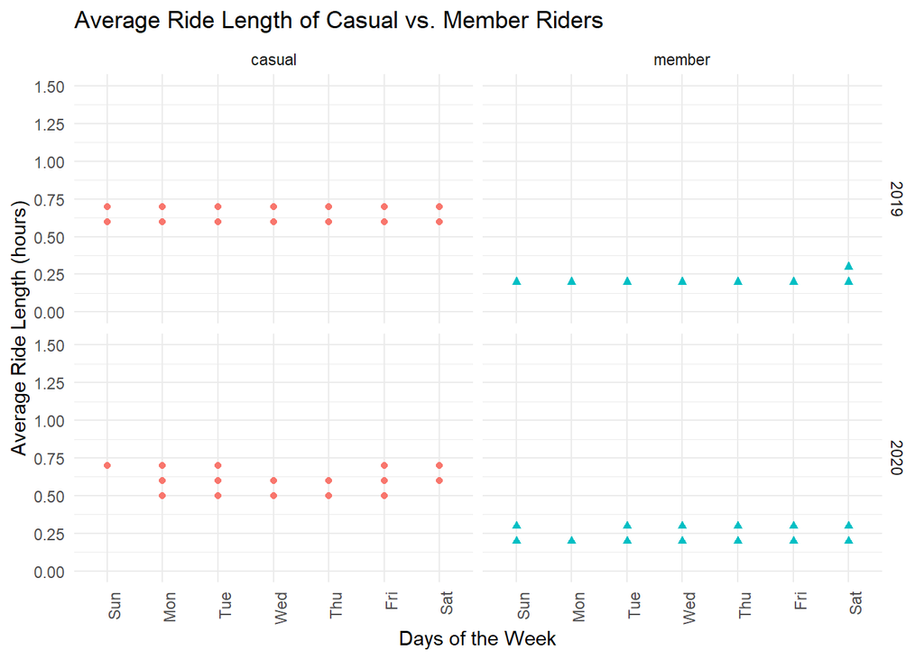

*Average ride lengths 2019-2020*

## ——————————————————————————

**Ride Counts and Hours Summary**

**Bike Ride Length Statistics 2019 - 2020**

| Period Year | Customer Type | Ride Count | Max. Ride Hours | Min. Ride Hours | Avg. Ride Hours |
| --- | --- | --- | --- | --- | --- |
| 2019 | casual | 879,321 | 23.99 | 0.02 | 0.66 |
| 2019 | member | 2,936,880 | 24.00 | 0.02 | 0.22 |
| 2020 | casual | 1,341,261 | 24.00 | 0.02 | 0.62 |
| 2020 | member | 2,134,825 | 24.00 | 0.02 | 0.26 |

## ——————————————————————————

**Ridership Numbers**

There was an increase in casual ridership during 2020 with a corresponding decrease in member usage with the  
onset of the pandemic lockdown. This may be due to consequence of the pandemic with its lock downs, closed businesses,  
increased mortality, and other pertinent factors,

Casual vs. Membership Riders by Year 2019-2020

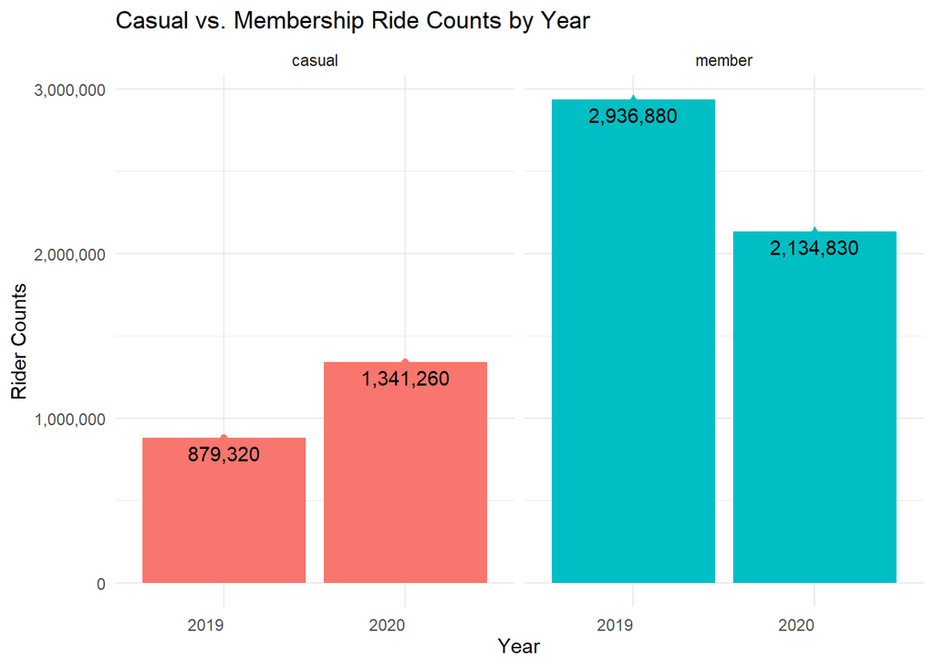

**Casual vs. Membership Riders by Year 2019-2020**

## ——————————————————————————

**Quarterly ridership 2019-2020**

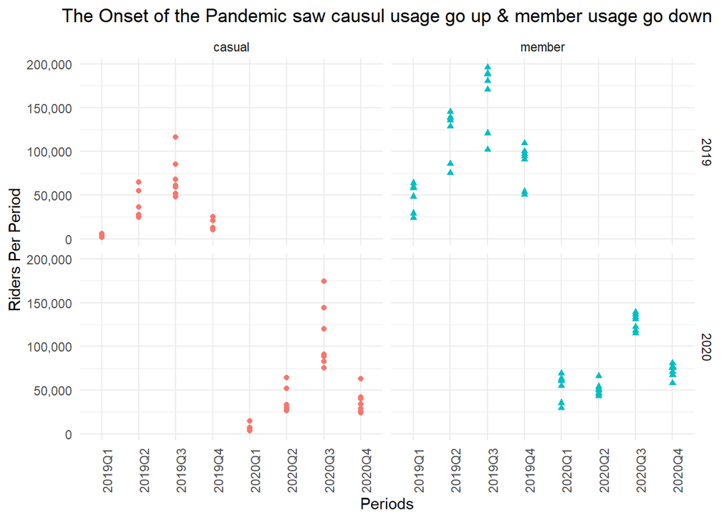

**Quarterly ridership 2019-2020**

## ——————————————————————————

**Casual vs. Member Monthly Ridership**

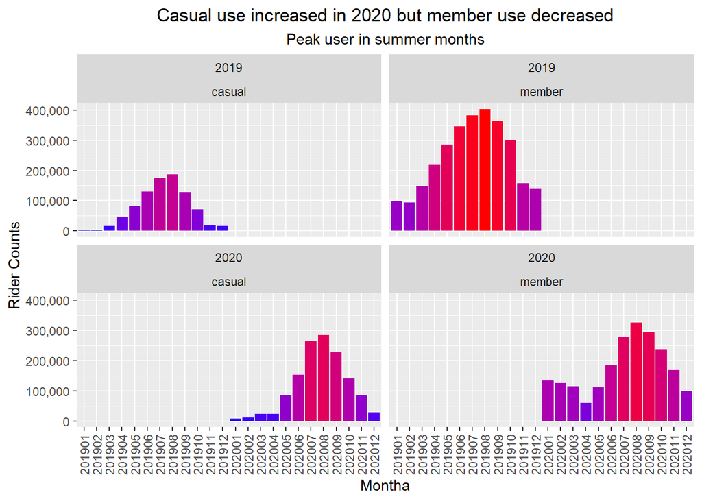

**2019-2020 Monthly Ridership**

## ——————————————————————————

**Ridership Numbers**

Ridership Numbers 2019–2020

| Period Year | Customer Type | Ride Count | Total Ride Count | Ride Percent | Current vs. Previous Ride Count |
| --- | --- | --- | --- | --- | --- |
| 2019 | casual | 879,321 | 3,816,201 | 23% | NA |
| 2019 | member | 2,936,880 | 3,816,201 | 77% | NA |
| 2020 | casual | 1,341,261 | 3,476,086 | 39% | 461,940 |
| 2020 | member | 2,134,825 | 3,476,086 | 61% | -802,055 |

**Ridership Statistics 2019-2020**

## ——————————————————————————

**Average Daily Ridership**

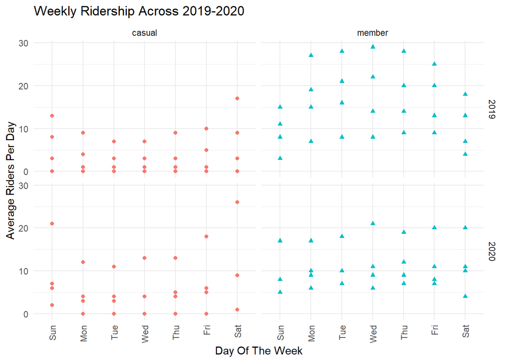

*Average Daily rider Counts across 2019-2020*

## ——————————————————————————

**Ride Lengths**

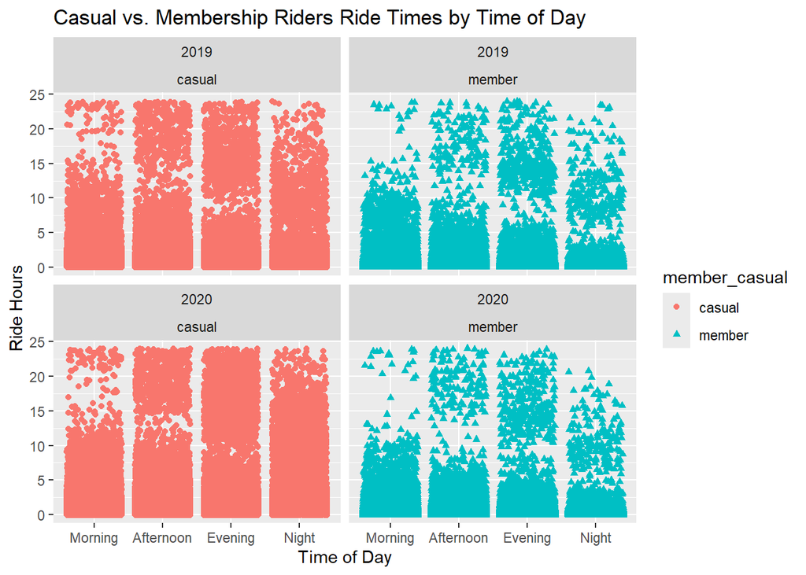

**Casual vs. Membership Riders Ride Times by Time of Day**

## ——————————————————————————

**Casual vs. Membership Riders Ride Times by Day of the Week**

Casual ridership increased overall in 2020 and members rode less. Overall there was a decrease in ridership in 2020.

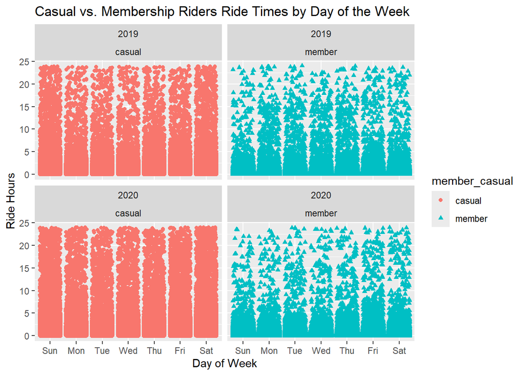

**Casual vs. Membership Riders Ride Times by Day of the Week**

## ——————————————————————————

**Types of Bikes**

Cyclistic did not provide information for the type of bikes it provided to its user for 2019, but information exists  
for 2020. Analysis below reflects that information. Cyclistic seems to offer three types of bikes with electric bikes  
seem to have been introduced in July of 2020.

*Bike Usage by Type Year & Month*

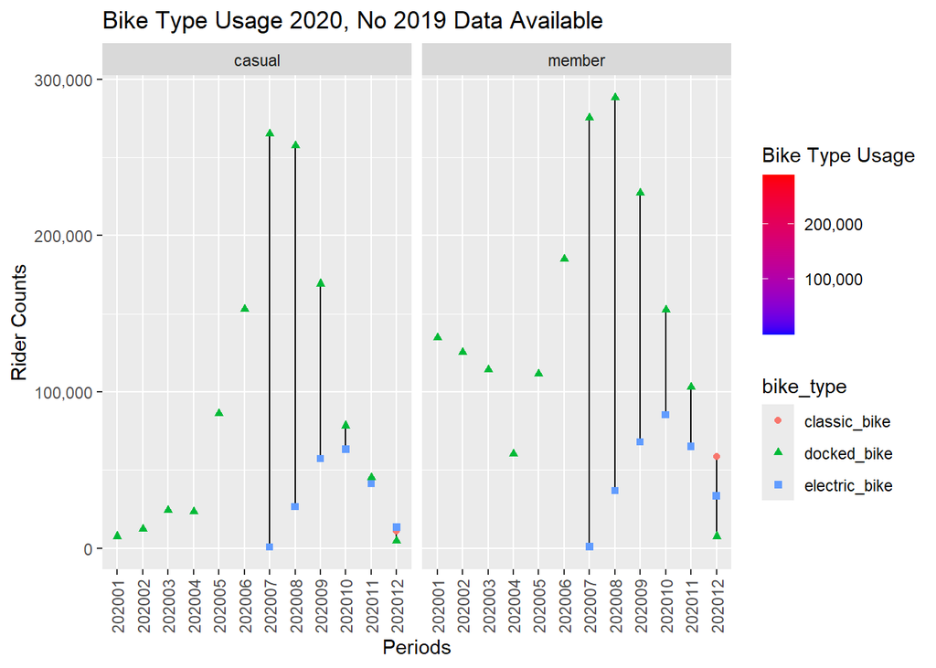

**Bike Type Usage by Year 2019-2020**

## ——————————————————————————

*Bike Usage by Type Year & Month*

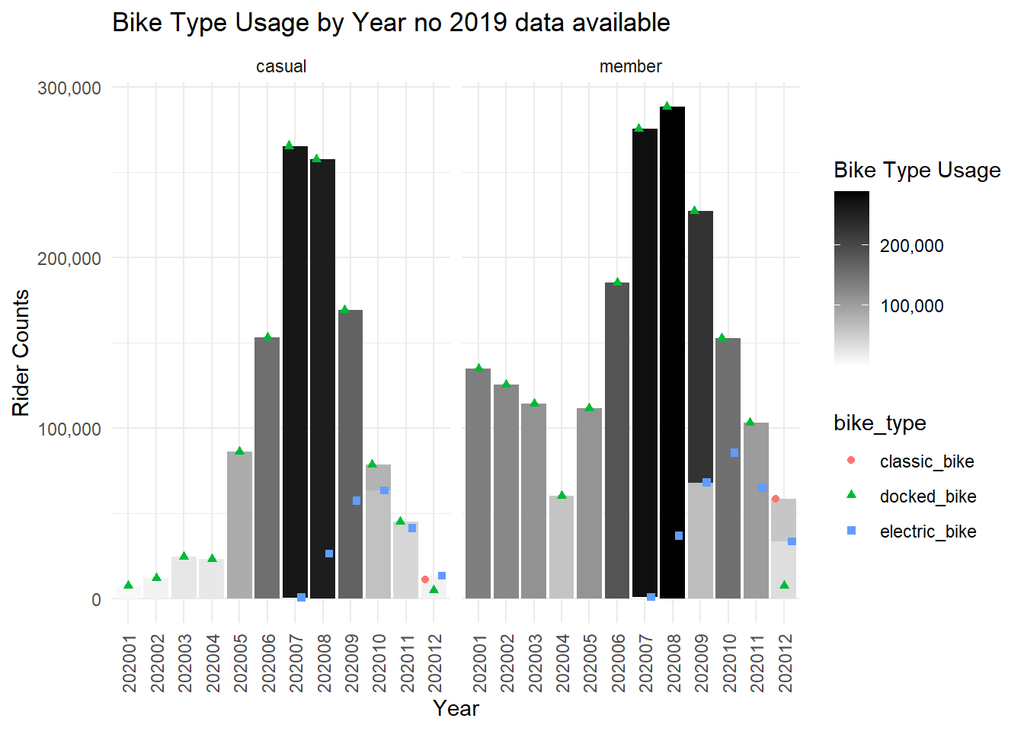

*Bike Type Usage by Year 2019-2020*

## ——————————————————————————

*Bike Usage by Type, Year & Quarter*

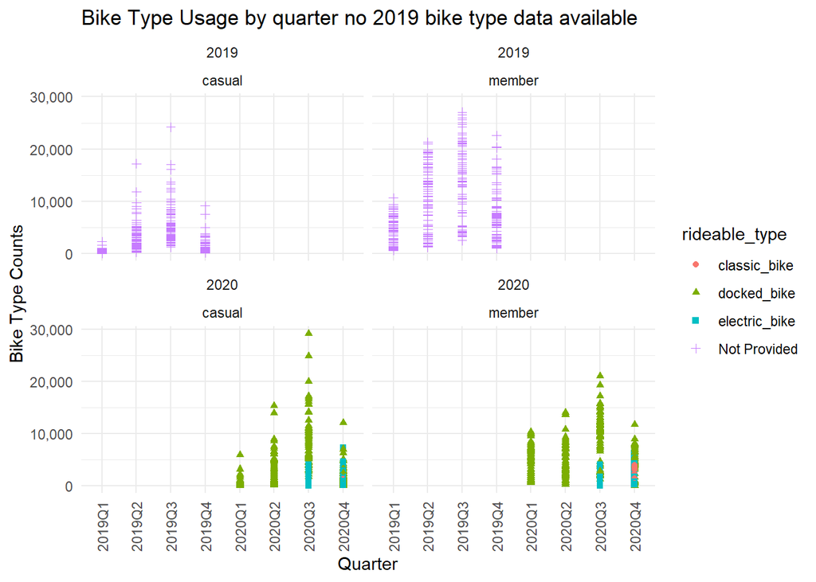

*Bike Type Usage by quarter 2019-2020*

## ——————————————————————————

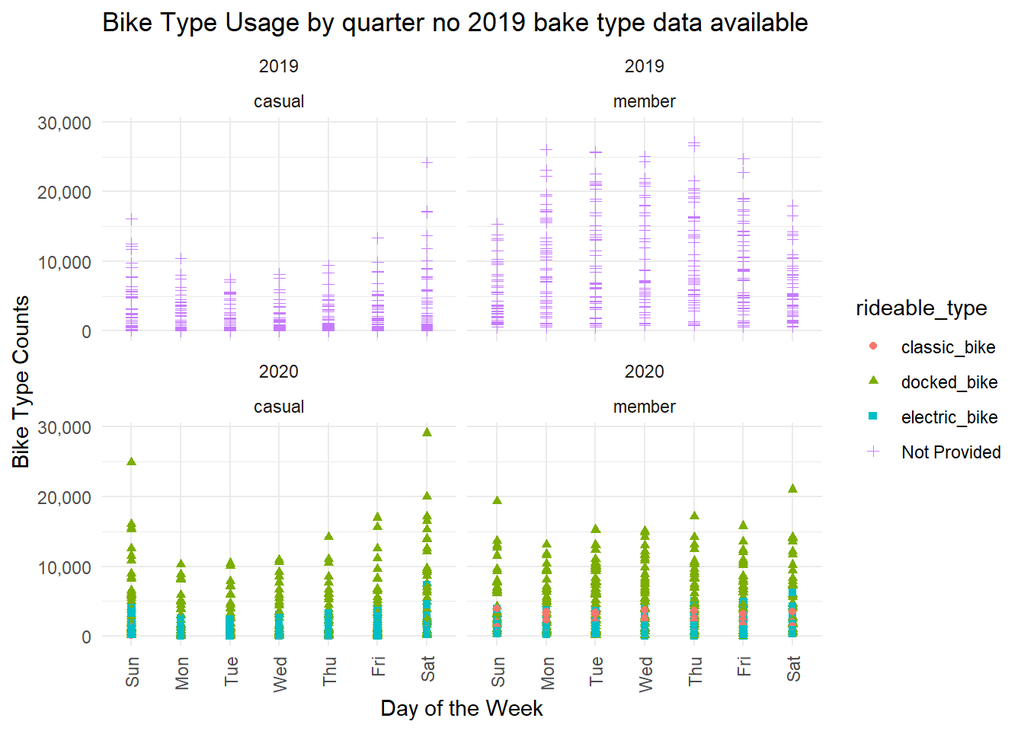

*Bike Type Usage by Day of the Week 2019-2020*

## ——————————————————————————

*Top Departure Stations for Casual Riders 2019-2020*

When considering where to focus planned added campaigns, piloting in the areas where casual use is heaviest would be  
prime candidates.

Top 20 Casual Departure Stations 2019–2020

| Station ID | Station Name | Ride Count |
| --- | --- | --- |
| 35 | Streeter Dr & Grand Ave | 78,648 |
| 76 | Lake Shore Dr & Monroe St | 58,661 |
| 90 | Millennium Park | 39,886 |
| 85 | Michigan Ave & Oak St | 34,448 |
| 268 | Lake Shore Dr & North Blvd | 31,622 |
| 3 | Shedd Aquarium | 30,029 |
| 177 | Theater on the Lake | 29,383 |
| 43 | Michigan Ave & Washington St | 22,224 |
| 255 | Indiana Ave & Roosevelt Rd | 20,709 |
| 6 | Dusable Harbor | 20,013 |
| 623 | Michigan Ave & 8th St | 18,852 |
| 341 | Adler Planetarium | 18,056 |
| 195 | Columbus Dr & Randolph St | 16,655 |
| 52 | Michigan Ave & Lake St | 16,333 |
| 141 | Clark St & Lincoln Ave | 16,273 |
| 94 | Clark St & Armitage Ave | 15,879 |
| 199 | Wabash Ave & Grand Ave | 15,275 |
| 176 | Clark St & Elm St | 15,177 |
| 26 | McClurg Ct & Illinois St | 14,286 |
| 249 | Montrose Harbor | 14,204 |

## ——————————————————————————

#### Conclusions and Recommendations

There are several avenues for improvement in the data collection process that would make this data set more  
valuable. For instance, cleaning up the GPS data by using the station name address GPS coordinates that are not  
provided available as the sole GP coordinates for each station. Information about existing membership numbers over  
time would provide better insight into membership usage statistics.

Depending on the size of the advertising budget; targeted advertising on trains, in and around bike facilities where  
casual usage is greater might garner additional memberships with discounts and promotions for membership. The top 20,  
departure stations would be good pilot campaign sites including including train and bus routes servicing these stations.

The next section of this presentation discusses analysis of the data beyond 2020 and how the data itself was  
stored, cleaned and analyzed.

# ———————————————————————-

## Appendix

*Findings Beyond 2019-2020*

While the assignment requested information across 2019 and 2020, at the time of this presentation, data existed  
up to up to March of 2025. Charting below is the fruit of that additional data.  
After that; a detailed explanation of the steps taken to clean and validate the data set used for this analysis  
is provided to validate the process and provides a means of replicating and verifying those steps.

| Period Year | Customer Type | Ride Count | Total Ride Count | Ride Percent | Current vs. Previous Ride Count |
| --- | --- | --- | --- | --- | --- |
| 2019 | casual | 879,321 | 3,816,201 | 23% | NA |
| 2019 | member | 2,936,880 | 3,816,201 | 77% | NA |
| 2020 | casual | 1,341,261 | 3,476,086 | 39% | 461,940 |
| 2020 | member | 2,134,825 | 3,476,086 | 61% | -802,055 |
| 2021 | casual | 2,491,412 | 5,505,869 | 45% | 1,150,151 |
| 2021 | member | 3,014,457 | 5,505,869 | 55% | 879,632 |
| 2022 | casual | 2,269,516 | 5,541,283 | 41% | -221,896 |
| 2022 | member | 3,271,767 | 5,541,283 | 59% | 257,310 |
| 2023 | casual | 2,000,546 | 5,563,905 | 36% | -268,970 |
| 2023 | member | 3,563,359 | 5,563,905 | 64% | 29,159 |
| 2024 | casual | 2,080,084 | 5,721,258 | 36% | 79,538 |
| 2024 | member | 3,641,174 | 5,721,258 | 64% | 77,815 |

*2019-2024 Ride Counts, Percentages, & Differences From the Previous Year*

# ———————————————————————-

*Casual vs. Member Ridership by Year Between 2019-2024*

While there was a significant drop in member ridership during the outset of the pandemic, in 2021, the member ridership  
returned to exceeded 2019 and continue tor rise through 2024. In 2021, cusual use increased significantly which makes  
sense considering the world was entering the second year of the pandemic. There was a decrease in casual ridership over  
the next two year. Without membership subscriptions numbers, there is no way to determine if this correlates to increased  
membership. This is a good place for futher analysis which I would have requested in a real world situation.

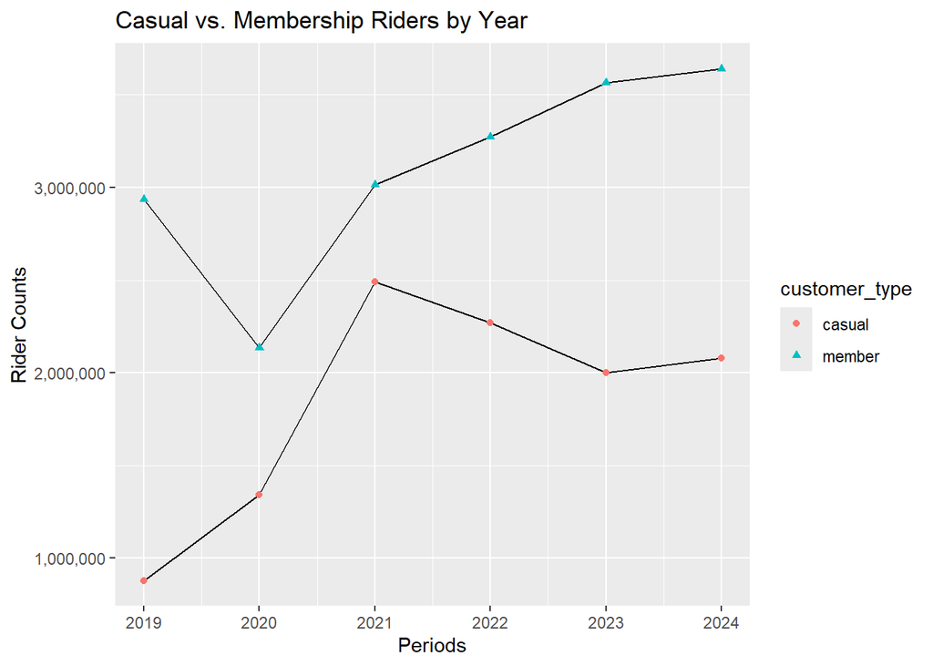

*Casual vs. Membership Ride Counts by Year 2019-2024*

## ——————————————————————————

*Ridership Over 2019-2024*

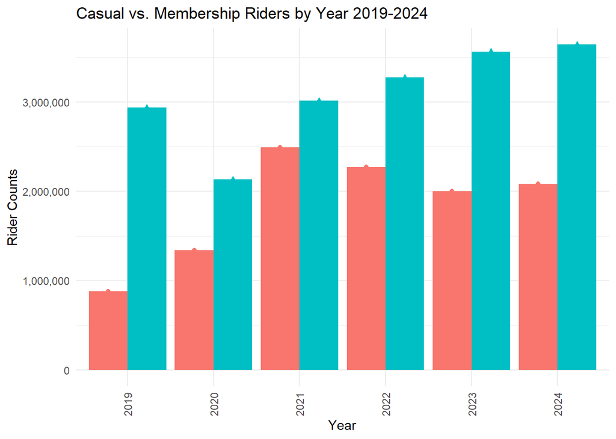

*Ridership Over 2019-2024*

## ——————————————————————————

Bike Ride Length Statistics 2019 - 2024

| Period Year | Customer Type | Ride Count | Max. Ride Hours | Min. Ride Hours | Avg. Ride Hours |
| --- | --- | --- | --- | --- | --- |
| 2019 | casual | 879,321 | 23.99 | 0.02 | 0.66 |
| 2019 | member | 2,936,880 | 24.00 | 0.02 | 0.22 |
| 2020 | casual | 1,341,261 | 24.00 | 0.02 | 0.62 |
| 2020 | member | 2,134,825 | 24.00 | 0.02 | 0.26 |
| 2021 | casual | 2,491,412 | 24.00 | 0.02 | 0.45 |
| 2021 | member | 3,014,457 | 24.00 | 0.02 | 0.23 |
| 2022 | casual | 2,269,516 | 24.00 | 0.02 | 0.37 |
| 2022 | member | 3,271,767 | 24.00 | 0.02 | 0.21 |
| 2023 | casual | 2,000,546 | 24.00 | 0.02 | 0.35 |
| 2023 | member | 3,563,359 | 24.00 | 0.02 | 0.21 |
| 2024 | casual | 2,080,084 | 24.00 | 0.02 | 0.36 |
| 2024 | member | 3,641,174 | 24.00 | 0.02 | 0.21 |

## ——————————————————————————

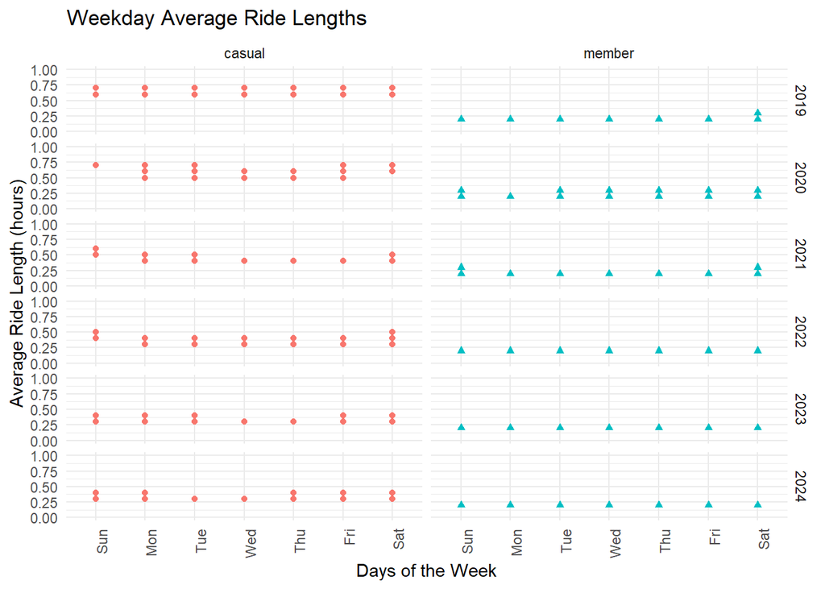

On average, casual riders tend to ride longer than member. This is consistent across all time periods.  
This does not mean than one or the other type of rider does not ride for longer periods.

## ——————————————————————————

*Bike Type usage 2019-2024*

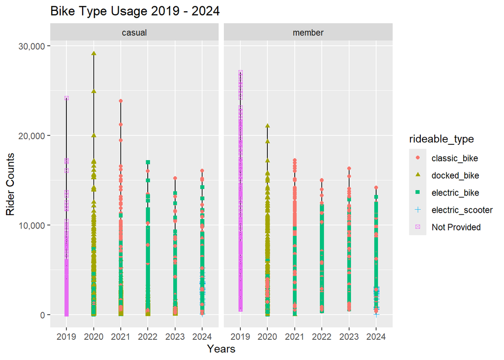

*Bike Type usage 2019-2024*

## ——————————————————————————

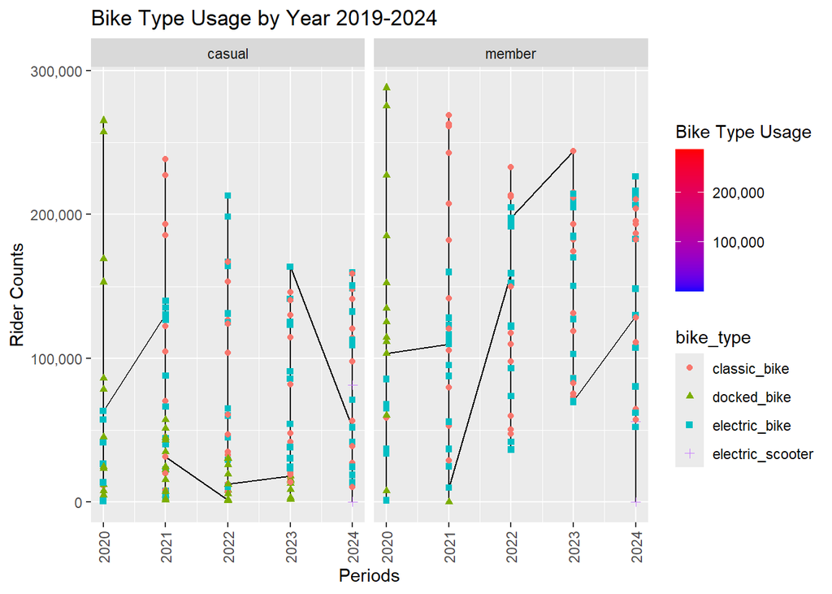

## ——————————————————————————

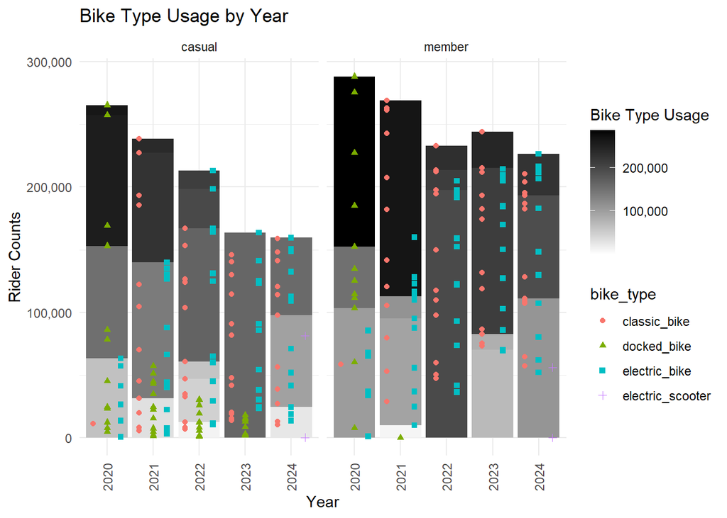

## ——————————————————————————

#### Packages & Libraries Loaded

##### Loaded Packages

- odbc - Provides interface between R and SQL Server.
- reticulate - Python libary.
- tidyverse - An opinionated collection of R packages designed for data science.
- scales - Scaling, converting from data values to perceptual properties.
- dplyr - A grammar of data manipulation
- ggtext _ Improved text rendering support for ggplot2
- ggdist _ Visualizations of distributions and uncertainty
- patchwork - Make it ridiculously simple to combine separate ggplots into the same graphic
- beeswarm - Bee swarm plots are similar to strip charts and are designed to show the  
  underlying distribution of the data but unlike strip charts, the data is arranged in a  
  way that avoids overlapping
- ggbeeswarm - Beeswarm plots (aka column scatter plots or violin scatter plots) are a way  
  of plotting points that would ordinarily overlap so that they fall next to each other  
  instead
- kableExtra - This package simplifies the way to manipulate the HTML or ‘LaTeX’ codes  
  generated by ‘kable()’ and allows users to construct complex tables and customize  
  styles using a readable syntax.

##### Loaded libraries

- odbc
- reticulate
- tidyverse
- scales
- dplyr
- ggtext
- ggdist
- glue
- patchwork
- beeswarm
- ggbeeswarm
- kableExtra

**SQL database connection and helper functions**

- Database Driver = SQL Server
- Database Name = GDAC
- Primary table = divvy-tripdata
- Staging table = divvy_trips_xxxx_qx

**Helper Functions**

- run_query - A function that executes a query that does not return a data set.
- fectch_data - A function that executes a query that returns a data set.

## ——————————————————————————

## Data: Initial preparation and import into analysis and/or staging tables

#### Database tables

- divvy-tripdata - Primary client data table for analysis
- divvy_trips_xxxx_qx - Staging table for data formatted differently than the norm
- div_py_pm_dow_tod - Analysis of ride count and lengths by year, month, customer type,  
  day of the week, and time of day reporting ride count and average ride length.
- div_py_pm_dow_tod_2019_2020 - Analysis of ride count and lengths by year, month,  
  customer type, day of the week, and time of day reporting ride count and average  
  ride length for 2019 and 2020.
- div_qtr_dow_tod_crc_mrc_arl - Analysis of ride counts and aver ride minutes parsed  
  parsed by year, quarter, day of the week, time of day, customer type with additional  
  sorting aids.
- div_qtr_dow_tod_crc_mrc_arl_1920 - Analysis of ride counts and aver ride minutes parsed  
  parsed by year, quarter, day of the week, time of day, customer type with additional  
  sorting aids for 2019 and 2020.
- divvy_Bike_type_analysis_1 - Analysis of bike type usage with max ride hours and average  
  ride hours parsed by year, period (YYYYMM), and bike type.
- divvy_bike_type_review - Analysis of ride counts by bike type and customer type parsed by  
  year, quarter, period (YYYMM), day of the week, time of day
- divvy_gps_problem - Bad GPS analysis table
- divvy_mbr_rct_pct - Summary analysis providing ride counts by customer type and correspdonding  
  percent of total
- divvy_ride_minutes_yr_dow_tod - Analysis of average ride minutes and hours parsed by year, customer  
  type, day of the week, and time of day.
- divvy_tripdata_1920 - Subset of divvy-tripdata for 2019-2020 parsed by year and period quarter (YYYYQX),
- divvy_trips_xxxx_qx - Staging table of non-standard data format for some data sets
- divvy-bad_trip_records- cleaning table
- divvy-trip_date_summary - Trip analysis table
- divvy-trip_date_summary_by_customer_type - Trip analysis table
- divvy-tripdata_duplicate_ride_id_counts - Duplicate rid ID data analysis table
- divvy-tripdata_duplicates - Duplicate records  
  *NOTE: time of day distilled into morning, afternoon, evening and night.*

#### Database views

- divvy_bad_trip_counts_by_period_vw
- divvy_mbr_pct_cas_vw
- divvy_pid_ct_dow_tod_rc_arl_vw
- divvy_pid_ct_dow_tod_rc_arl_vw2
- divvy-trip_date_summary_by_period_customer_type_vw  
  *NOTE: some views may have been deprecated to a table for performance reasons*

#### Global variables

**Environment Setting**  
run_python_code setting = 1

- 0 = run
- 1 = do not run

run_sql_code setting = 1

- 0 = run data rebuild
- 1 = don’t run
- 3 = install/build complete

#### Database tables

- divvy-tripdata - Client data for cleaning & analysis
- divvy_tripdata - Client data for analysis 2019-2020
- divvy_trips_xxxx_qx - Staging table for abnormally formatted client data
- div_py_pm_dow_tod - Analysis table
- div_py_pm_dow_tod_2019_2020 - Analysis table for 2019-2020
- div_qtr_dow_tod_crc_mrc_arl - Analysis table
- div_qtr_dow_tod_crc_mrc_arl_1920 - Analysis table for 2019-2020
- divvy_gps_problem - Bad GPS analysis table
- divvy_mbr_rct_pct - Analysis table
- divvy_ri_rss_stse_mc_rl_dow_down_maen_tod_1920 - Analysis table for 2019-2020
- divvy_tripdata_1920- Subset of divvy-tripdata for 2019-2020
- divvy-bad_trip_records- cleaning table
- divvy-trip_date_summary - Analysis table
- divvy-trip_date_summary_by_customer_type - Analysis table
- divvy-tripdata_duplicate_ride_id_counts - Duplicate data analysis table
- divvy-tripdata_duplicates - Duplicate records

#### Database views

- divvy_bad_trip_counts_by_period_vw
- divvy_mbr_pct_cas_vw
- divvy_pid_ct_dow_tod_rc_arl_vw
- divvy_pid_ct_dow_tod_rc_arl_vw2
- divvy-trip_date_summary_by_period_customer_type_vw

**Create data table divvy-data**

```
## Skipping query execution.
```

```
## SQL code:
##
## /*** THE TABLE WILL BE CREATED IF run_sql IS SET TO 3 ***/
## --USE [GDAC]
## --GO
##
## /****** Object:  Table [dbo].[divvy-tripdata]    Script Date: 4/15/2025 10:13:51 AM ******/
## IF  EXISTS (SELECT * FROM sys.objects WHERE object_id = OBJECT_ID(N'[dbo].[divvy-tripdata]') AND type in (N'U'))
## DROP TABLE [dbo].[divvy-tripdata]
## GO
##
## /****** Object:  Table [dbo].[divvy-tripdata]    Script Date: 4/15/2025 10:13:51 AM ******/
## SET ANSI_NULLS ON
## GO
##
## SET QUOTED_IDENTIFIER ON
## GO
##
## CREATE TABLE [dbo].[divvy-tripdata](
##  [ride_id] [varchar](20) NULL,
##  [rideable_type] [varchar](30) NULL,
##  [started_at] [datetime] NULL,
##  [ended_at] [datetime] NULL,
##  [start_station_name] [varchar](50) NULL,
##  [start_station_id] [int] NULL,
##  [end_station_name] [varchar](50) NULL,
##  [end_station_id] [int] NULL,
##  [start_lat] [decimal](8, 6) NULL,
##  [start_lng] [decimal](9, 6) NULL,
##  [end_lat] [decimal](8, 6) NULL,
##  [end_lng] [decimal](9, 6) NULL,
##  [member_casual] [varchar](10) NULL,
##  [ride_length] [time](7) NULL,
##  [day_of_week] [int] NULL
## ) ON [PRIMARY]
## GO
```

**Create staging table divvy_trips_xxxx_qx**

```
## Skipping query execution.
```

```
## SQL code:
##
## /****** Object:  Table [dbo].[divvy_trips_xxxx_qx]    Script Date: 4/21/2025 11:23:08 AM ******/
## IF  EXISTS (SELECT * FROM sys.objects WHERE object_id = OBJECT_ID(N'[dbo].[divvy_trips_xxxx_qx]') AND type in (N'U'))
## DROP TABLE [dbo].[divvy_trips_xxxx_qx]
## GO
##
## /****** Object:  Table [dbo].[divvy_trips_xxxx_qx]    Script Date: 4/21/2025 11:23:08 AM ******/
## SET ANSI_NULLS ON
## GO
##
## SET QUOTED_IDENTIFIER ON
## GO
##
## CREATE TABLE [dbo].[divvy_trips_xxxx_qx](
##  [trip_id] [varchar](20) NULL,
##  [start_time] [datetime] NULL,
##  [end_time] [datetime] NULL,
##  [bikeid] [varchar](50) NULL,
##  [tripduration] [varchar](100) NULL,
##  [from_station_id] [varchar](100) NULL,
##  [from_station_name] [varchar](100) NULL,
##  [to_station_id] [varchar](100) NULL,
##  [to_station_name] [varchar](100) NULL,
##  [usertype] [varchar](100) NULL,
##  [gender] [varchar](50) NULL,
##  [birthyear] [varchar](50) NULL,
##  [ride_length] [varchar](50) NULL,
##  [day_of_week] [varchar](50) NULL
## ) ON [PRIMARY]
## GO
```

**Create divvy-files table**

- NOTE: This table and the file list is stores is required for the data load stored procedure to work

```
## Skipping query execution.
```

```
## SQL code:
##
## /****** Object:  Table [dbo].[divvy-files]    Script Date: 5/15/2025 1:34:05 PM ******/
## IF  EXISTS (SELECT * FROM sys.objects WHERE object_id = OBJECT_ID(N'[dbo].[divvy-files]') AND type in (N'U'))
## DROP TABLE [dbo].[divvy-files]
## GO
##
## /****** Object:  Table [dbo].[divvy-files]    Script Date: 5/15/2025 1:34:05 PM ******/
## SET ANSI_NULLS ON
## GO
##
## SET QUOTED_IDENTIFIER ON
## GO
##
## CREATE TABLE [dbo].[divvy-files](
##  [file_name] [varchar](100) NULL,
##  [py_tgt] [varchar](100) NULL,
##  [type] [int] NULL
## ) ON [PRIMARY]
## GO
```

**Create div_py_pm_dow_tod table**

```
## Skipping creation of div_py_pm_dow_tod table.
```

```
## SQL code:
##
## /****** Object:  Table [dbo].[div_py_pm_dow_tod]    Script Date: 5/15/2025 12:18:41 PM ******/
## IF  EXISTS (SELECT * FROM sys.objects WHERE object_id = OBJECT_ID(N'[dbo].[div_py_pm_dow_tod]') AND type in (N'U'))
## DROP TABLE [dbo].[div_py_pm_dow_tod]
## GO
##
## /****** Object:  Table [dbo].[div_py_pm_dow_tod]    Script Date: 5/15/2025 12:18:41 PM ******/
## SET ANSI_NULLS ON
## GO
##
## SET QUOTED_IDENTIFIER ON
## GO
##
## CREATE TABLE [dbo].[div_py_pm_dow_tod](
##  [period_yr] [int] NULL,
##  [period_mo] [int] NULL,
##  [customer_type] [varchar](10) NULL,
##  [dow] [varchar](3) NULL,
##  [time_of_day] [varchar](9) NOT NULL,
##  [ride_count] [int] NULL,
##  [avg_ride_length] [int] NULL
## ) ON [PRIMARY]
## GO
```

**Create div_py_pm_dow_tod_2019_2020 table**

```
## Skipping Creation of div_py_pm_dow_tod_2019_2020 table.
```

```
## SQL code:
##
## /****** Object:  Table [dbo].[div_py_pm_dow_tod_2019_2020]    Script Date: 5/15/2025 12:20:13 PM ******/
## IF  EXISTS (SELECT * FROM sys.objects WHERE object_id = OBJECT_ID(N'[dbo].[div_py_pm_dow_tod_2019_2020]') AND type in (N'U'))
## DROP TABLE [dbo].[div_py_pm_dow_tod_2019_2020]
## GO
##
## /****** Object:  Table [dbo].[div_py_pm_dow_tod_2019_2020]    Script Date: 5/15/2025 12:20:13 PM ******/
## SET ANSI_NULLS ON
## GO
##
## SET QUOTED_IDENTIFIER ON
## GO
##
## CREATE TABLE [dbo].[div_py_pm_dow_tod_2019_2020](
##  [period_yr] [int] NULL,
##  [period_mo] [int] NULL,
##  [customer_type] [varchar](10) NULL,
##  [dow] [varchar](3) NULL,
##  [time_of_day] [varchar](9) NOT NULL,
##  [ride_count] [int] NULL,
##  [avg_ride_length] [int] NULL
## ) ON [PRIMARY]
## GO
```

**Create div_qtr_dow_tod_crc_mrc_arl table**

```
## Skipping Creation of div_qtr_dow_tod_crc_mrc_arl table.
```

```
## SQL code:
##
## /****** Object:  Table [dbo].[div_qtr_dow_tod_crc_mrc_arl]    Script Date: 5/15/2025 1:13:37 PM ******/
## IF  EXISTS (SELECT * FROM sys.objects WHERE object_id = OBJECT_ID(N'[dbo].[div_qtr_dow_tod_crc_mrc_arl]') AND type in (N'U'))
## DROP TABLE [dbo].[div_qtr_dow_tod_crc_mrc_arl]
## GO
##
## /****** Object:  Table [dbo].[div_qtr_dow_tod_crc_mrc_arl]    Script Date: 5/15/2025 1:13:37 PM ******/
## SET ANSI_NULLS ON
## GO
##
## SET QUOTED_IDENTIFIER ON
## GO
##
## CREATE TABLE [dbo].[div_qtr_dow_tod_crc_mrc_arl](
##  [period_yr] [varchar](4) NOT NULL,
##  [prd_qtr] [varchar](6) NOT NULL,
##  [day_of_week_name] [varchar](10) NOT NULL,
##  [time_of_day] [varchar](10) NOT NULL,
##  [casual_ride_count] [numeric](18, 0) NOT NULL,
##  [casual_avg_ride_minutes] [numeric](18, 0) NOT NULL,
##  [member_ride_count] [numeric](18, 0) NOT NULL,
##  [member_avg_ride_minutes] [numeric](18, 0) NOT NULL,
##  [day_of_week_num] [int] NOT NULL,
##  [time_of_day_order] [int] NOT NULL
## ) ON [PRIMARY]
## GO
```

**Create div_qtr_dow_tod_crc_mrc_arl_1920 table**

```
## Skipping Creation of div_qtr_dow_tod_crc_mrc_arl_1920 table.
```

```
## SQL code:
##
## /****** Object:  Table [dbo].[div_qtr_dow_tod_crc_mrc_arl_1920]    Script Date: 5/15/2025 1:14:49 PM ******/
## IF  EXISTS (SELECT * FROM sys.objects WHERE object_id = OBJECT_ID(N'[dbo].[div_qtr_dow_tod_crc_mrc_arl_1920]') AND type in (N'U'))
## DROP TABLE [dbo].[div_qtr_dow_tod_crc_mrc_arl_1920]
## GO
##
## /****** Object:  Table [dbo].[div_qtr_dow_tod_crc_mrc_arl_1920]    Script Date: 5/15/2025 1:14:49 PM ******/
## SET ANSI_NULLS ON
## GO
##
## SET QUOTED_IDENTIFIER ON
## GO
##
## CREATE TABLE [dbo].[div_qtr_dow_tod_crc_mrc_arl_1920](
##  [period_yr] [varchar](4) NOT NULL,
##  [prd_qtr] [varchar](6) NOT NULL,
##  [day_of_week_name] [varchar](10) NOT NULL,
##  [time_of_day] [varchar](10) NOT NULL,
##  [casual_ride_count] [numeric](18, 0) NOT NULL,
##  [casual_avg_ride_minutes] [numeric](18, 0) NOT NULL,
##  [member_ride_count] [numeric](18, 0) NOT NULL,
##  [member_avg_ride_minutes] [numeric](18, 0) NOT NULL,
##  [day_of_week_num] [int] NOT NULL,
##  [time_of_day_order] [int] NOT NULL
## ) ON [PRIMARY]
## GO
```

**Create divvy_gps_problem table**

```
## Skipping Creation of divvy_gps_problem table.
```

```
## SQL code:
##
## /****** Object:  Table [dbo].[divvy_gps_problem]    Script Date: 5/15/2025 1:15:55 PM ******/
## IF  EXISTS (SELECT * FROM sys.objects WHERE object_id = OBJECT_ID(N'[dbo].[divvy_gps_problem]') AND type in (N'U'))
## DROP TABLE [dbo].[divvy_gps_problem]
## GO
##
## /****** Object:  Table [dbo].[divvy_gps_problem]    Script Date: 5/15/2025 1:15:55 PM ******/
## SET ANSI_NULLS ON
## GO
##
## SET QUOTED_IDENTIFIER ON
## GO
##
## CREATE TABLE [dbo].[divvy_gps_problem](
##  [station_id] [varchar](100) NULL,
##  [latitude] [decimal](8, 6) NULL,
##  [longitude] [decimal](8, 6) NULL,
##  [rcount] [int] NULL
## ) ON [PRIMARY]
## GO
```

**Create divvy_mbr_rct_pct table**

```
## Skipping Creation of divvy_mbr_rct_pct table.
```

```
## SQL code:
##
## /****** Object:  Table [dbo].[divvy_mbr_rct_pct]    Script Date: 5/15/2025 1:16:35 PM ******/
## IF  EXISTS (SELECT * FROM sys.objects WHERE object_id = OBJECT_ID(N'[dbo].[divvy_mbr_rct_pct]') AND type in (N'U'))
## DROP TABLE [dbo].[divvy_mbr_rct_pct]
## GO
##
## /****** Object:  Table [dbo].[divvy_mbr_rct_pct]    Script Date: 5/15/2025 1:16:35 PM ******/
## SET ANSI_NULLS ON
## GO
##
## SET QUOTED_IDENTIFIER ON
## GO
##
## CREATE TABLE [dbo].[divvy_mbr_rct_pct](
##  [period_yr] [int] NOT NULL,
##  [casual_ride_count] [float] NOT NULL,
##  [member_ride_count] [float] NOT NULL,
##  [total_ride_count] [float] NOT NULL,
##  [member_as_percent_of_total] [varchar](4) NOT NULL,
##  [casual_as_percent_of_total] [varchar](4) NOT NULL
## ) ON [PRIMARY]
## GO
```

**Create divvy_tripdata_1920 table**

```
## Skipping Creation of divvy_tripdata_1920 table.
```

```
## SQL code:
##
## /****** Object:  Table [dbo].[divvy_tripdata_1920]    Script Date: 5/15/2025 1:19:00 PM ******/
## IF  EXISTS (SELECT * FROM sys.objects WHERE object_id = OBJECT_ID(N'[dbo].[divvy_tripdata_1920]') AND type in (N'U'))
## DROP TABLE [dbo].[divvy_tripdata_1920]
## GO
##
## /****** Object:  Table [dbo].[divvy_tripdata_1920]    Script Date: 5/15/2025 1:19:00 PM ******/
## SET ANSI_NULLS ON
## GO
##
## SET QUOTED_IDENTIFIER ON
## GO
##
## CREATE TABLE [dbo].[divvy_tripdata_1920](
##  [ride_id] [varchar](20) NULL,
##  [rideable_type] [varchar](30) NULL,
##  [started_at] [datetime] NULL,
##  [ended_at] [datetime] NULL,
##  [start_station_name] [varchar](100) NULL,
##  [start_station_id] [varchar](100) NULL,
##  [end_station_name] [varchar](100) NULL,
##  [end_station_id] [varchar](100) NULL,
##  [start_lat] [decimal](8, 6) NULL,
##  [start_lng] [decimal](9, 6) NULL,
##  [end_lat] [decimal](8, 6) NULL,
##  [end_lng] [decimal](9, 6) NULL,
##  [member_casual] [varchar](10) NULL,
##  [ride_length] [nvarchar](8) NULL,
##  [day_of_week] [int] NULL
## ) ON [PRIMARY]
## GO
```

**Create divvy-bad_trip_records table**

```
## Skipping Creation of divvy-bad_trip_records table.
```

```
## SQL code:
##
## /****** Object:  Table [dbo].[divvy-bad_trip_records]    Script Date: 5/15/2025 1:31:50 PM ******/
## IF  EXISTS (SELECT * FROM sys.objects WHERE object_id = OBJECT_ID(N'[dbo].[divvy-bad_trip_records]') AND type in (N'U'))
## DROP TABLE [dbo].[divvy-bad_trip_records]
## GO
##
## /****** Object:  Table [dbo].[divvy-bad_trip_records]    Script Date: 5/15/2025 1:31:50 PM ******/
## SET ANSI_NULLS ON
## GO
##
## SET QUOTED_IDENTIFIER ON
## GO
##
## CREATE TABLE [dbo].[divvy-bad_trip_records](
##  [ride_id] [varchar](20) NULL,
##  [rideable_type] [varchar](30) NULL,
##  [started_at] [datetime] NULL,
##  [ended_at] [datetime] NULL,
##  [start_station_name] [varchar](100) NULL,
##  [start_station_id] [varchar](100) NULL,
##  [end_station_name] [varchar](100) NULL,
##  [end_station_id] [varchar](100) NULL,
##  [start_lat] [decimal](8, 6) NULL,
##  [start_lng] [decimal](9, 6) NULL,
##  [end_lat] [decimal](8, 6) NULL,
##  [end_lng] [decimal](9, 6) NULL,
##  [member_casual] [varchar](10) NULL,
##  [ride_length] [nvarchar](8) NULL,
##  [day_of_week] [int] NULL,
##  [reason] [varchar](100) NULL
## ) ON [PRIMARY]
## GO
```

**Create divvy-trip_date_summary table**

```
## Skipping Creation of divvy-trip_date_summary table.
```

```
## SQL code:
##
## /****** Object:  Table [dbo].[divvy-trip_date_summary]    Script Date: 5/19/2025 1:49:25 PM ******/
## IF  EXISTS (SELECT * FROM sys.objects WHERE object_id = OBJECT_ID(N'[dbo].[divvy-trip_date_summary]') AND type in (N'U'))
## DROP TABLE [dbo].[divvy-trip_date_summary]
## GO
##
## /****** Object:  Table [dbo].[divvy-trip_date_summary]    Script Date: 5/19/2025 1:49:25 PM ******/
## SET ANSI_NULLS ON
## GO
##
## SET QUOTED_IDENTIFIER ON
## GO
##
## CREATE TABLE [dbo].[divvy-trip_date_summary](
##  [trip_date] [date] NULL,
##  [total_trips] [int] NULL,
##  [unique_start_times] [int] NULL,
##  [first_trip] [datetime] NULL,
##  [last_rtip] [datetime] NULL
## ) ON [PRIMARY]
## GO
```

**Create divvy-trip_date_summary_by_customer_type table**

```
## Skipping Creation of divvy-trip_date_summary_by_customer_type table.
```

```
## SQL code:
##
## /****** Object:  Table [dbo].[divvy-trip_date_summary_by_customer_type]    Script Date: 5/19/2025 1:50:57 PM ******/
## IF  EXISTS (SELECT * FROM sys.objects WHERE object_id = OBJECT_ID(N'[dbo].[divvy-trip_date_summary_by_customer_type]') AND type in (N'U'))
## DROP TABLE [dbo].[divvy-trip_date_summary_by_customer_type]
## GO
##
## /****** Object:  Table [dbo].[divvy-trip_date_summary_by_customer_type]    Script Date: 5/19/2025 1:50:57 PM ******/
## SET ANSI_NULLS ON
## GO
##
## SET QUOTED_IDENTIFIER ON
## GO
##
## CREATE TABLE [dbo].[divvy-trip_date_summary_by_customer_type](
##  [trip_date] [date] NULL,
##  [member_type] [varchar](10) NULL,
##  [total_trips] [int] NULL,
##  [unique_start_times] [int] NULL,
##  [first_trip] [datetime] NULL,
##  [last_rtip] [datetime] NULL
## ) ON [PRIMARY]
## GO
```

**Create divvy-tripdata_duplicate_ride_id_counts table**

```
## Skipping Creation of divvy-tripdata_duplicate_ride_id_counts table.
```

```
## SQL code:
##
## IF  EXISTS (SELECT * FROM sys.objects WHERE object_id = OBJECT_ID(N'[dbo].[divvy-tripdata_duplicate_ride_id_counts]') AND type in (N'U'))
## DROP TABLE [dbo].[divvy-tripdata_duplicate_ride_id_counts]
## GO
##
## /****** Object:  Table [dbo].[divvy-tripdata_duplicate_ride_id_counts]    Script Date: 5/19/2025 1:51:58 PM ******/
## SET ANSI_NULLS ON
## GO
##
## SET QUOTED_IDENTIFIER ON
## GO
##
## CREATE TABLE [dbo].[divvy-tripdata_duplicate_ride_id_counts](
##  [ride_id] [varchar](20) NULL,
##  [DuplicateCount] [int] NULL
## ) ON [PRIMARY]
## GO
```

**Create divvy-tripdata_duplicates table**

```
## Skipping Creation of divvy-tripdata_duplicates table.
```

```
## SQL code:
##
## /****** Object:  Table [dbo].[divvy-tripdata_duplicates]    Script Date: 5/19/2025 1:52:48 PM ******/
## IF  EXISTS (SELECT * FROM sys.objects WHERE object_id = OBJECT_ID(N'[dbo].[divvy-tripdata_duplicates]') AND type in (N'U'))
## DROP TABLE [dbo].[divvy-tripdata_duplicates]
## GO
##
## /****** Object:  Table [dbo].[divvy-tripdata_duplicates]    Script Date: 5/19/2025 1:52:48 PM ******/
## SET ANSI_NULLS ON
## GO
##
## SET QUOTED_IDENTIFIER ON
## GO
##
## CREATE TABLE [dbo].[divvy-tripdata_duplicates](
##  [ride_id] [varchar](20) NULL,
##  [rideable_type] [varchar](30) NULL,
##  [started_at] [datetime] NULL,
##  [ended_at] [datetime] NULL,
##  [start_station_name] [varchar](100) NULL,
##  [start_station_id] [varchar](100) NULL,
##  [end_station_name] [varchar](100) NULL,
##  [end_station_id] [varchar](100) NULL,
##  [start_lat] [decimal](8, 6) NULL,
##  [start_lng] [decimal](9, 6) NULL,
##  [end_lat] [decimal](8, 6) NULL,
##  [end_lng] [decimal](9, 6) NULL,
##  [member_casual] [varchar](10) NULL,
##  [ride_length] [nvarchar](8) NULL,
##  [day_of_week] [int] NULL
## ) ON [PRIMARY]
## GO
```

###### Database views

**Create view divvy_bad_trip_counts_by_period_vw**

```
## Skipping Creation of divvy_bad_trip_counts_by_period_vw view.
```

```
## SQL code:
##
## /****** Object:  View [dbo].[divvy_bad_trip_counts_by_period_vw]    Script Date: 5/19/2025 1:53:54 PM ******/
## DROP VIEW [dbo].[divvy_bad_trip_counts_by_period_vw]
## GO
##
## /****** Object:  View [dbo].[divvy_bad_trip_counts_by_period_vw]    Script Date: 5/19/2025 1:53:54 PM ******/
## SET ANSI_NULLS ON
## GO
##
## SET QUOTED_IDENTIFIER ON
## GO
##
##
## CREATE VIEW [dbo].[divvy_bad_trip_counts_by_period_vw]
## AS
## Select TOP 100 PERCENT CAST(YEAR(started_at) AS char(4))+
##  CASE MONTH(started_at) WHEN 1 THEN '01' WHEN 2 THEN '01' WHEN 3 THEN '01'
##      WHEN 4 THEN '02' WHEN 5 THEN '02' WHEN 6 THEN '02'
##      WHEN 7 THEN '03' WHEN 8 THEN '03' WHEN 9 THEN '03'
##      WHEN 10 THEN '04' WHEN 11 THEN '04' WHEN 12 THEN '04'
##      END AS bd_period
##  , reason
##  , count(*) AS rcount
## FROM [dbo].[divvy-bad_trip_records]
## GROUP BY CAST(YEAR(started_at) AS char(4))+
##  CASE MONTH(started_at) WHEN 1 THEN '01' WHEN 2 THEN '01' WHEN 3 THEN '01'
##      WHEN 4 THEN '02' WHEN 5 THEN '02' WHEN 6 THEN '02'
##      WHEN 7 THEN '03' WHEN 8 THEN '03' WHEN 9 THEN '03'
##      WHEN 10 THEN '04' WHEN 11 THEN '04' WHEN 12 THEN '04'
##      END
##      ,reason
## ORDER BY bd_period, reason
##
## GO
```

**Create view divvy_mbr_pct_cas_vw**

[output not shown]

```
## SQL code:
##
## /****** Object:  View [dbo].[divvy_mbr_pct_cas_vw]    Script Date: 5/19/2025 1:55:26 PM ******/
## DROP VIEW [dbo].[divvy_mbr_pct_cas_vw]
## GO
##
## /****** Object:  View [dbo].[divvy_mbr_pct_cas_vw]    Script Date: 5/19/2025 1:55:26 PM ******/
## SET ANSI_NULLS ON
## GO
##
## SET QUOTED_IDENTIFIER ON
## GO
##
## CREATE   VIEW [dbo].[divvy_mbr_pct_cas_vw]
## AS
## SELECT TOP (100) PERCENT period_yr
##  , ROUND(CAST(casual_ride_count AS FLOAT),0) AS casual_ride_count
##  , ROUND(CAST(member_ride_count AS FLOAT),0)AS member_ride_count
##  , ROUND(CAST(total_ride_count AS FLOAT),0) AS total_ride_count
##  , CASE WHEN member_ride_count > 0 THEN
##      CAST(ROUND(CAST(member_ride_count AS FLOAT) / total_ride_count * 100, 2) AS VARCHAR(10)) + '%'
##          ELSE NULL END AS member_as_percent_of_total
##  , CASE WHEN casual_ride_count > 0 THEN
##      CAST(ROUND(CAST(casual_ride_count AS FLOAT) / total_ride_count * 100, 2) AS VARCHAR(10)) + '%'
##          ELSE NULL END AS casual_as_percent_of_total
## FROM (
##      SELECT c1.period_yr
##      , t2.total_ride_count
##      , SUM(CASE WHEN customer_type = 'casual' THEN ride_count ELSE 0 END) AS casual_ride_count
##      , SUM(CASE WHEN customer_type = 'member' THEN ride_count ELSE 0 END) AS member_ride_count
##      FROM (
##              SELECT YEAR(started_at) AS period_yr
##                  , member_casual AS customer_type
##                  , COUNT(ride_id) AS ride_count
##                 FROM            dbo.[divvy-tripdata] t1
##                 WHERE        (YEAR(started_at) < 2025)
##                 GROUP BY YEAR(started_at), member_casual
##          ) AS c1
##          LEFT JOIN (select YEAR(started_at) AS period_yr, COUNT(ride_id) AS total_ride_count FROM [dbo].[divvy-tripdata] GROUP BY YEAR(started_at)
##                                  ) t2 ON c1.period_yr = t2.period_yr
##              GROUP BY c1.period_yr, t2.total_ride_count
##      ) AS final
## ORDER BY period_yr
## GO
```

**Create view divvy_pid_ct_dow_tod_rc_arl_vw**

[output not shown]

```
## SQL code:
##
## /****** Object:  View [dbo].[divvy_pid_ct_dow_tod_rc_arl_vw]    Script Date: 5/19/2025 1:56:19 PM ******/
## DROP VIEW [dbo].[divvy_pid_ct_dow_tod_rc_arl_vw]
## GO
##
## /****** Object:  View [dbo].[divvy_pid_ct_dow_tod_rc_arl_vw]    Script Date: 5/19/2025 1:56:19 PM ******/
## SET ANSI_NULLS ON
## GO
##
## SET QUOTED_IDENTIFIER ON
## GO
##
##
## CREATE   VIEW [dbo].[divvy_pid_ct_dow_tod_rc_arl_vw]
## AS
## SELECT TOP (100) PERCENT
##   --CAST([period_yr] AS varchar(4)) AS period_year,
##   CAST([period_yr] AS varchar(4)) + RIGHT('0' + CAST([period_mo] AS varchar(2)), 2) AS period_id,
##   [dow],
##   [customer_type],
##   [time_of_day],
##   SUM([ride_count]) AS sum_ride_count,
##   AVG([avg_ride_length]) AS avg_ride_length_2
## FROM [GDAC].[dbo].[div_py_pm_dow_tod_2019_2020]
## GROUP BY CAST([period_yr] AS varchar(4)) + RIGHT('0' + CAST([period_mo] AS varchar(2)), 2) , dow, customer_type, time_of_day
## ORDER BY period_id
##  , CASE dow
##      WHEN 'Sun' THEN 1
##      WHEN 'Mon' THEN 2
##      WHEN 'Tue' THEN 3
##      WHEN 'Wed' THEN 4
##      WHEN 'Thu' THEN 5
##      WHEN 'Fri' THEN 6
##      ELSE 7
##  END
##  , customer_type
##  , CASE time_of_day
##      WHEN 'morning' THEN 1
##      WHEN 'afternoon' THEN 2
##      ELSE 3
##  END
##
## GO
```

**Create view divvy_pid_ct_dow_tod_rc_arl_vw2**

```
## Skipping Creation of view divvy_pid_ct_dow_tod_rc_arl_vw2.
```

```
## SQL code:
##
## /****** Object:  View [dbo].[divvy_pid_ct_dow_tod_rc_arl_vw2]    Script Date: 5/19/2025 1:57:24 PM ******/
## DROP VIEW [dbo].[divvy_pid_ct_dow_tod_rc_arl_vw2]
## GO
##
## /****** Object:  View [dbo].[divvy_pid_ct_dow_tod_rc_arl_vw2]    Script Date: 5/19/2025 1:57:24 PM ******/
## SET ANSI_NULLS ON
## GO
##
## SET QUOTED_IDENTIFIER ON
## GO
##
##
##
## CREATE   VIEW [dbo].[divvy_pid_ct_dow_tod_rc_arl_vw2]
## AS
## SELECT TOP (100) PERCENT
##   --CAST([period_yr] AS varchar(4)) AS period_year,
##   CAST([period_yr] AS varchar(4)) + RIGHT('0' + CAST([period_mo] AS varchar(2)), 2) AS period_id,
##   [dow],
##   [customer_type],
##   [time_of_day],
##   SUM([ride_count]) AS sum_ride_count,
##   AVG([avg_ride_length]) AS avg_ride_length_2
## FROM [GDAC].[dbo].[div_py_pm_dow_tod]
## GROUP BY CAST([period_yr] AS varchar(4)) + RIGHT('0' + CAST([period_mo] AS varchar(2)), 2) , dow, customer_type, time_of_day
## ORDER BY period_id
##  , CASE dow
##      WHEN 'Sun' THEN 1
##      WHEN 'Mon' THEN 2
##      WHEN 'Tue' THEN 3
##      WHEN 'Wed' THEN 4
##      WHEN 'Thu' THEN 5
##      WHEN 'Fri' THEN 6
##      ELSE 7
##  END
##  , customer_type
##  , CASE time_of_day
##      WHEN 'morning' THEN 1
##      WHEN 'afternoon' THEN 2
##      ELSE 3
##  END
##
## GO
```

**Create view divvy-trip_date_summary_by_period_customer_type_vw**

```
## Skipping Creation of view divvy-trip_date_summary_by_period_customer_type_vw.
```

```
## SQL code:
##
## /****** Object:  View [dbo].[divvy-trip_date_summary_by_period_customer_type_vw]    Script Date: 5/19/2025 1:58:18 PM ******/
## DROP VIEW [dbo].[divvy-trip_date_summary_by_period_customer_type_vw]
## GO
##
## /****** Object:  View [dbo].[divvy-trip_date_summary_by_period_customer_type_vw]    Script Date: 5/19/2025 1:58:18 PM ******/
## SET ANSI_NULLS ON
## GO
##
## SET QUOTED_IDENTIFIER ON
## GO
##
##
## CREATE VIEW [dbo].[divvy-trip_date_summary_by_period_customer_type_vw]
## AS
## SELECT        TOP (100) PERCENT CAST(YEAR(trip_date) AS char(4)) +
##  CASE
##      WHEN MONTH(trip_date) IN (1, 2, 3) THEN '01'
##      WHEN MONTH(trip_date) IN (4, 5, 6) THEN '02'
##      WHEN MONTH(trip_date) IN (7, 8, 9) THEN '03'
##      WHEN MONTH(trip_date) IN (10, 11, 12) THEN '04'
##  END AS trip_period, member_type
##  , SUM(total_trips) AS total_trips
##  , MIN(trip_date) AS first_trip
##  , MAX(trip_date) AS last_rtip
## FROM            dbo.[divvy-trip_date_summary_by_customer_type]
## GROUP BY CAST(YEAR(trip_date) AS char(4)) +
##  CASE
##      WHEN MONTH(trip_date) IN (1, 2, 3) THEN '01'
##      WHEN MONTH(trip_date) IN (4, 5, 6) THEN '02'
##      WHEN MONTH(trip_date) IN (7, 8, 9) THEN '03'
##      WHEN MONTH(trip_date) IN (10, 11, 12) THEN '04'
##  END, member_type
## ORDER BY trip_period, member_type
## GO
```

## ——————————————————————————

## Data Load Process

SQL: get the list of files that are to be imported into the primary analysis table and  
staging tables. This includes flagging which files will imported where  
Python is used to iterate trough the files and insure they would load into SQL Server.  
* Add two column names to the header; ride_length & day_of_week.  
* Add two commas on each data line.  
* Add a hard line return to the end of each line.  
* Each modified file’s content was added to a new file.

**Load divvy-files table**

```
## Skipping query execution.
```

```
## SQL code:
##
## DECLARE  @return_value int
##
## EXEC @return_value = [dbo].[up_get_divvy_file_list]
##
## SELECT   'Return Value' = @return_value
##
## GO
```

**Python first stage data cleanup file set 1**

```python
import csv
import re
import os
from pathlib import Path

# === Helper Function Definitions ===

def clean_numeric_field(value):
    """Remove commas from numeric fields."""
    if re.fullmatch(r'\d{1,3}(,\d{3})*(\.\d+)?', value):
        return value.replace(',', '')
    return value

def process_csv(input_file, output_file):
    """Clean numeric fields and add extra columns."""
    if not os.path.exists(input_file):
        print(f"Input file not found: {input_file}")
        return

    with open(input_file, 'r', encoding='utf-8', newline='') as infile, \
         open(output_file, 'w', encoding='utf-8', newline='\n') as outfile:

        reader = csv.reader(infile, delimiter=',', quotechar='"')
        writer = csv.writer(outfile, delimiter=',', quotechar='"', quoting=csv.QUOTE_MINIMAL)

        headers = next(reader)
        headers += ['ride_length', 'day_of_week']
        writer.writerow(headers)

        line_count = 0
        for row in reader:
            cleaned_row = [clean_numeric_field(field) for field in row]
            cleaned_row += ['', '']
            writer.writerow(cleaned_row)
            line_count += 1

        print(f"Processed {line_count} rows. Output saved to: {output_file}")

# === Batch Processing ===

if run_python_code == 0:
    input_dir = Path(r'\\tabitha\gdac$\CS1')
    output_dir = input_dir  # Or change to another Path if needed

    file_names = [
        "202004-divvy-tripdata.csv", "202005-divvy-tripdata.csv", "202006-divvy-tripdata.csv",
        "202007-divvy-tripdata.csv", "202008-divvy-tripdata.csv", "202009-divvy-tripdata.csv",
        "202010-divvy-tripdata.csv", "202011-divvy-tripdata.csv", "202012-divvy-tripdata.csv",
        "202101-divvy-tripdata.csv", "202102-divvy-tripdata.csv", "202103-divvy-tripdata.csv",
        "202104-divvy-tripdata.csv", "202105-divvy-tripdata.csv", "202106-divvy-tripdata.csv",
        "202107-divvy-tripdata.csv", "202108-divvy-tripdata.csv", "202109-divvy-tripdata.csv",
        "202110-divvy-tripdata.csv", "202111-divvy-tripdata.csv", "202112-divvy-tripdata.csv",
        "202201-divvy-tripdata.csv", "202202-divvy-tripdata.csv", "202203-divvy-tripdata.csv",
        "202204-divvy-tripdata.csv", "202205-divvy-tripdata.csv", "202206-divvy-tripdata.csv",
        "202207-divvy-tripdata.csv", "202208-divvy-tripdata.csv", "202209-divvy-publictripdata.csv",
        "202210-divvy-tripdata.csv", "202211-divvy-tripdata.csv", "202212-divvy-tripdata.csv",
        "202301-divvy-tripdata.csv", "202302-divvy-tripdata.csv", "202303-divvy-tripdata.csv",
        "202304-divvy-tripdata.csv", "202305-divvy-tripdata.csv", "202306-divvy-tripdata.csv",
        "202307-divvy-tripdata.csv", "202308-divvy-tripdata.csv", "202309-divvy-tripdata.csv",
        "202310-divvy-tripdata.csv", "202311-divvy-tripdata.csv", "202312-divvy-tripdata.csv",
        "202401-divvy-tripdata.csv", "202402-divvy-tripdata.csv", "202403-divvy-tripdata.csv",
        "202404-divvy-tripdata.csv", "202405-divvy-tripdata.csv", "202406-divvy-tripdata.csv",
        "202407-divvy-tripdata.csv", "202408-divvy-tripdata.csv", "202409-divvy-tripdata.csv",
        "202410-divvy-tripdata.csv", "202411-divvy-tripdata.csv", "202412-divvy-tripdata.csv",
        "202501-divvy-tripdata.csv", "202502-divvy-tripdata.csv", "202503-divvy-tripdata.csv",
        "Divvy_Trips_2020_Q1.csv"
    ]

    for file_name in file_names:
        input_path = input_dir / file_name
        output_name = file_name.replace(".csv", "_PyTgt.csv")
        output_path = output_dir / output_name
        process_csv(str(input_path), str(output_path))
else:
    print("run_python_code flag set to 1 -- skipping batch processing.")
```

```
## run_python_code flag set to 1 -- skipping batch processing.
```

**Python first stage data cleanup file set 2**

```python
import csv
import re
import os
from pathlib import Path

def clean_numeric_field(value):
    if re.fullmatch(r'\d{1,3}(,\d{3})*(\.\d+)?', value):
        return value.replace(',', '')
    return value

def process_csv(input_file, output_file):
    if not os.path.exists(input_file):
        print(f"Input file not found: {input_file}")
        return

    with open(input_file, 'r', encoding='utf-8', newline='') as infile, \
         open(output_file, 'w', encoding='utf-8', newline='\n') as outfile:

        reader = csv.reader(infile, delimiter=',', quotechar='"')
        writer = csv.writer(outfile, delimiter=',', quotechar='"', quoting=csv.QUOTE_MINIMAL)

        headers = next(reader)
        headers += ['ride_length', 'day_of_week']
        writer.writerow(headers)

        line_count = 0
        for row in reader:
            cleaned_row = [clean_numeric_field(field) for field in row]
            cleaned_row += ['', '']
            writer.writerow(cleaned_row)
            line_count += 1

        print(f"Processed {line_count} rows. Output saved to: {output_file}")

# Conditional execution block
if run_python_code == 0:
    input_dir = Path(r'\\tabitha\gdac$\CS1')
    output_dir = input_dir

    file_names = [
        "Divvy_Trips_2019_Q1.csv",
        "Divvy_Trips_2019_Q2.csv",
        "Divvy_Trips_2019_Q3.csv",
        "Divvy_Trips_2019_Q4.csv"
    ]

    for file_name in file_names:
        input_path = input_dir / file_name
        output_name = file_name.replace(".csv", "_PyTgt.csv")
        output_path = output_dir / output_name
        process_csv(str(input_path), str(output_path))
else:
    print("run_python_code flag set to 1 -- skipping batch processing.")
```

```
## run_python_code flag set to 1 -- skipping batch processing.
```

## ——————————————————————————

### Load files into tables

The SQL query that loads the .CSV files into the tables using CURSORS and makes calls  
to the disk subsystem which uses file system calls that include back slashes in the  
file paths which r interprets as code in R YAML.  
Due to this, the process was converted to a stored procedure.  
I encountered data problems with the data that were collected near the end of 2024 to  
March of 2025; it would seem that some form of data collection paradigm shift occurred  
in June of 2024.

**divvy-tripdata records**  
CSV files with YYYYMM-divvy-tripdata naming convention that have valid dates import  
into the gdac.dbo.divvy-tripdata table without issue. Additionally, the 2020 quarterly  
file also imports into the divvy-tripdata table without transformation.  
The process use the SQL “BULK INSERT” function to load the .CSV files leverage the CURSOR  
function to iterate through a list of files to import. Due to the volume of data provided  
for this lab assignment, over 30 million records as of this writing, the process takes  
quite a bit of time depending on your disk subsystem, processor speed and RAM.

**divvy_xxxx_qx records** CSV files containing 2019 data by quarter required additionally data transformation due  
to differences in column layouts and missing columns.  
Files with the naming convention Divvy_Trips_2019_Qx.csv must be loaded into a  
staging table, transformed prior to insertion into gdac.dbo.divvy-trips_xxxx_qx after  
they have been modified using python to add two new columns, ride_length and day_of_week,  
stripping out commas from numerical values encapsulated by double quotes, and adding two  
commas at the end of each data line to create the new field data placeholders. Again,  
while I could manually import the data, this was inefficient; I needed a quicker and more  
streamline method. On top of that, Excel could not open the larger quarterly files for  
manipulation without data loss.  
Using the fore mentioned xml format file, the import of these files is facilitate by a  
separate query process built into the stored procedure to facilitate this. the stored  
procedure contains flags to allow for import of all or specific .CSV file sets

**divvy_Trips_YYYY_Qx BCP import format file**  
A format file for the quarterly tables that matched the staging table was required to load  
these files

```xml
    <?xml version="1.0"?>
    <BCPFORMAT xmlns="http://schemas.microsoft.com/sqlserver/2004/bulkload/format" xmlns:xsi="http://www.w3.org/2001/XMLSchema-instance">
     <RECORD>
      <FIELD ID="1" xsi:type="CharTerm" TERMINATOR="," MAX_LENGTH="20"
        COLLATION="SQL_Latin1_General_CP1_CS_AS"/>
      <FIELD ID="2" xsi:type="CharTerm" TERMINATOR="," MAX_LENGTH="24"/>
      <FIELD ID="3" xsi:type="CharTerm" TERMINATOR="," MAX_LENGTH="24"/>
      <FIELD ID="4" xsi:type="CharTerm" TERMINATOR="," MAX_LENGTH="50"
        COLLATION="SQL_Latin1_General_CP1_CS_AS"/>
      <FIELD ID="5" xsi:type="CharTerm" TERMINATOR="," MAX_LENGTH="100"
        COLLATION="SQL_Latin1_General_CP1_CS_AS"/>
      <FIELD ID="6" xsi:type="CharTerm" TERMINATOR="," MAX_LENGTH="100"
        COLLATION="SQL_Latin1_General_CP1_CS_AS"/>
      <FIELD ID="7" xsi:type="CharTerm" TERMINATOR="," MAX_LENGTH="100"
        COLLATION="SQL_Latin1_General_CP1_CS_AS"/>
      <FIELD ID="8" xsi:type="CharTerm" TERMINATOR="," MAX_LENGTH="100"
        COLLATION="SQL_Latin1_General_CP1_CS_AS"/>
      <FIELD ID="9" xsi:type="CharTerm" TERMINATOR="," MAX_LENGTH="100"
        COLLATION="SQL_Latin1_General_CP1_CS_AS"/>
      <FIELD ID="10" xsi:type="CharTerm" TERMINATOR="," MAX_LENGTH="100"
        COLLATION="SQL_Latin1_General_CP1_CS_AS"/>
      <FIELD ID="11" xsi:type="CharTerm" TERMINATOR="," MAX_LENGTH="50"
        COLLATION="SQL_Latin1_General_CP1_CS_AS"/>
      <FIELD ID="12" xsi:type="CharTerm" TERMINATOR="," MAX_LENGTH="50"
        COLLATION="SQL_Latin1_General_CP1_CS_AS"/>
      <FIELD ID="13" xsi:type="CharTerm" TERMINATOR="," MAX_LENGTH="50"
        COLLATION="SQL_Latin1_General_CP1_CS_AS"/>
      <FIELD ID="14" xsi:type="CharTerm" TERMINATOR="\r\n" MAX_LENGTH="50"
        COLLATION="SQL_Latin1_General_CP1_CS_AS"/>
     </RECORD>
     <ROW>
      <COLUMN SOURCE="1" NAME="trip_id" xsi:type="SQLVARYCHAR"/>
      <COLUMN SOURCE="2" NAME="start_time" xsi:type="SQLDATETIME"/>
      <COLUMN SOURCE="3" NAME="end_time" xsi:type="SQLDATETIME"/>
      <COLUMN SOURCE="4" NAME="bikeid" xsi:type="SQLVARYCHAR"/>
      <COLUMN SOURCE="5" NAME="tripduration" xsi:type="SQLVARYCHAR"/>
      <COLUMN SOURCE="6" NAME="from_station_id" xsi:type="SQLVARYCHAR"/>
      <COLUMN SOURCE="7" NAME="from_station_name" xsi:type="SQLVARYCHAR"/>
      <COLUMN SOURCE="8" NAME="to_station_id" xsi:type="SQLVARYCHAR"/>
      <COLUMN SOURCE="9" NAME="to_station_name" xsi:type="SQLVARYCHAR"/>
      <COLUMN SOURCE="10" NAME="usertype" xsi:type="SQLVARYCHAR"/>
      <COLUMN SOURCE="11" NAME="gender" xsi:type="SQLVARYCHAR"/>
      <COLUMN SOURCE="12" NAME="birthyear" xsi:type="SQLVARYCHAR"/>
      <COLUMN SOURCE="13" NAME="ride_length" xsi:type="SQLVARYCHAR" NULLABLE="YES"/>
      <COLUMN SOURCE="14" NAME="day_of_week" xsi:type="SQLVARYCHAR" NULLABLE="YES"/>
     </ROW>
    </BCPFORMAT>
```

**Load divvy-tripdata table**

```
## Skipping query execution.
```

```
## SQL code:
##
## --
## TRUNCATE TABLE [dbo].[divvy-tripdata]
##
## DECLARE  @return_value int -- 0 = All / 1 = tripdata / 2 = Quarterly
## EXEC @return_value = [dbo].[up_load_divvy]
##          @task = 1 -- Default, load all
## SELECT   'Return Value' = @return_value
## --
```

**Load gdac.dbo.divvy_trips_xxxx_qx**

```
## Skipping query execution.
```

```
## SQL code:
##
## --
## TRUNCATE TABLE [dbo].[divvy_trips_xxxx_qx]
##
## DECLARE  @return_value int -- 0 = All / 1 = tripdata / 2 = Quarterly
## EXEC @return_value = [dbo].[up_load_divvy]
##          @task = 2 -- Default, load all
## SELECT   'Return Value' = @return_value
## --
```

### Data prep and Cleaning

**Data differences**  
Data differences between standard tripdata and trip_xxxx_qx  
The Quarterly data for 2019 used user type identitifier “Customer”  
and “Subscriber”, the rest of the data tables, including the  
trips_2020_Q1 data used “casual” and “member”.  
The 2019 data in the trip_xxxx_qx table was updated to change the  
records to replace “Customer” with “casual”, and “Subscriber” with  
“member”.

**Standardize member_casual values in quarterly data**  
* Set “customer” values to “casual

```
## Skipping query execution.
```

```
## SQL code:
##
## --
## -- casual
## --
## UPDATE dtxq
##   SET usertype = 'casual'
## FROM [dbo].[divvy_trips_xxxx_qx] dtxq where usertype = 'Customer'
## --
```

- Set “Subscriber” values to “member”

```
## Skipping query execution.
```

```
## SQL code:
##
## --
## -- member
## --
## UPDATE dtxq
## SET usertype = 'member'
## FROM [dbo].[divvy_trips_xxxx_qx] dtxq where usertype = 'Subscriber'
## --
```

**Add quarterly records to trip data table**  
Due to the differences in layout and content, it was necessary to transform the quarterly data  
prior to integrating the records into the main data set.

```
## Skipping query execution.
```

```
## SQL code:
##
## --
## INSERT INTO [dbo].[divvy-tripdata](
##   [ride_id]
##      ,[started_at]
##      ,[ended_at]
##      ,[rideable_type]
##      ,[start_station_name]
##      ,[start_station_id]
##      ,[end_station_name]
##      ,[end_station_id]
##      ,[start_lat]
##      ,[start_lng]
##      ,[end_lat]
##      ,[end_lng]
##      ,[member_casual]
##      ,[ride_length]
##      ,[day_of_week]
##        )
##  SELECT
##      [trip_id] AS ride_id
##      ,[start_time]
##      ,[end_time]
##      ,'' AS rideable_type
##      ,[from_station_name] AS stat_station_name
##      ,[from_station_id] AS start_station_id
##      ,[to_station_name] AS end_station_name
##      ,[to_station_id] AS end_station_id
##      ,0 AS start_lat -- Field not in source
##      ,0 AS start_lng -- Field not in source
##      ,0 AS end_lat -- Field not in source
##      ,0 AS end_lng -- Field not in source
##      ,[usertype] AS member_casual
##      ,CONVERT(char(10),end_time-start_time, 108) AS ride_length
##      ,CAST(CAST(ROUND(DATEPART(WEEKDAY,start_time), 0) AS INT) AS VARCHAR(1)) AS day_of_week
##    FROM [GDAC].[dbo].[divvy_trips_xxxx_qx]
##   --
##   -- (3818004 rows affected)
##   --
```

**Update divvy-tripdata ride_length & day_of_week calculations**

```
## Skipping query execution.
```

```
## SQL code:
##
## --
## Update divvy-tripdata ride_length & day_of_week calculations
## --
## UPDATE td
## set ride_length = CONVERT(char(10),ended_at-started_at, 108)
##  ,day_of_week =CAST(CAST(ROUND(DATEPART(WEEKDAY,started_at), 0) AS INT) AS VARCHAR(1))
## FROM [dbo].[divvy-tripdata] td;
## --
```

###### Backup and delete duplicate records

- Get duplicate ride_id records and their counts

**Purge duplicate record counts**

```
## Skipping query execution.
```

```
## SQL code:
##
## --
## TRUNCATE TABLE [dbo].[divvy-tripdata_duplicate_ride_id_counts];
## --
```

**Backup of duplicate record_id records**

```
## Skipping query execution.
```

```
## SQL code:
##
## -- Get duplicate ride_id and counts
## --
## TRUNCATE TABLE [dbo].[divvy-tripdata_duplicate_ride_id_counts];
## --
## INSERT INTO [dbo].[divvy-tripdata_duplicate_ride_id_counts]
## SELECT ride_id, COUNT(*) AS DuplicateCount
## FROM dbo.[divvy-tripdata]
## GROUP BY ride_id
## HAVING COUNT(*) > 1
## ORDER BY DuplicateCount DESC;
## --
## -- 420 rows affected
## --
```

**Backup duplicate records**

```
## Skipping query execution.
```

```
## SQL code:
##
## --
## TRUNCATE TABLE [dbo].[divvy-tripdata_duplicates];
##
## INSERT INTO [dbo].[divvy-tripdata_duplicates]
##  SELECT * FROM [dbo].[divvy-tripdata]
##  WHERE ride_id IN (SELECT ride_id FROM [dbo].[divvy-tripdata_duplicate_ride_id_counts]);
## --
```

**Delete duplicate records from divvy-tripdata**

```
## Skipping query execution.
```

```
## SQL code:
##
## --
## DELETE FROM [dbo].[divvy-tripdata]
## WHERE ride_id IN (SELECT ride_id
##                   FROM [dbo].[divvy-tripdata_duplicate_ride_id_counts]
##                   );
## --
```

###### Backup & purge bad trip-data records

**Initialize divvy_bad_trip_table**

```
## Skipping query execution.
```

```
## SQL code:
##
## -- ! Flush target table
## TRUNCATE TABLE [dbo].[divvy-bad_trip_records];
## --
```

**A. Backup equal start and end datetime records**

```
## Skipping query execution.
```

```
## SQL code:
##
## -- A. Equal start and end datetime
## --SELECT COUNT(*) FROM dbo.[divvy-tripdata] WHERE started_at = ended_at;
## INSERT INTO [dbo].[divvy-bad_trip_records]
## SELECT *, 'started_at and ended_at are identical'
## FROM dbo.[divvy-tripdata]
## WHERE started_at = ended_at;
## --
```

**B. Backup midnight-only timestamps (possibly incomplete records)**

```
## Skipping query execution.
```

```
## SQL code:
##
## INSERT INTO [dbo].[divvy-bad_trip_records]
## SELECT *, 'started_at time is 00:00:00'
## FROM dbo.[divvy-tripdata]
## WHERE CAST(started_at AS TIME) = '00:00:00'
## AND ride_id NOT IN (SELECT ride_id FROM [dbo].[divvy-bad_trip_records]);  -- Avoid duplicates
```

**C. Backup NULL or zero-length rides**

```
## Skipping query execution.
```

```
## SQL code:
##
## INSERT INTO [dbo].[divvy-bad_trip_records]
## SELECT *, 'Calculated ride_length is null or 00:00:00'
## FROM dbo.[divvy-tripdata]
## WHERE (ride_length IS NULL OR ride_length = '00:00:00')
## AND ride_id NOT IN (SELECT ride_id FROM [dbo].[divvy-bad_trip_records]);
```

**D. Backup rides lasting over 24 hours**

```
## Skipping query execution.
```

```
## SQL code:
##
## INSERT INTO [dbo].[divvy-bad_trip_records]
## SELECT *, 'ride_length longer than 24 hours'
## FROM dbo.[divvy-tripdata]
## WHERE DATEDIFF(HOUR, started_at, ended_at) > 24
## AND ride_id NOT IN (SELECT ride_id FROM [dbo].[divvy-bad_trip_records]);
```

**E. Backup rides with ended before they started**

```
## Skipping query execution.
```

```
## SQL code:
##
## INSERT INTO [dbo].[divvy-bad_trip_records]
## SELECT *, 'rides that ended before they started'
## FROM [dbo].[divvy-tripdata]
## WHERE ended_at < started_at;
```

```
## Skipping query execution.
```

[output not shown]

**G-1. Bad records to delete count**

```
## Skipping query execution.
```

```
## SQL code:
##
## SELECT COUNT(*) AS RecordsToDelete
## FROM dbo.[divvy-tripdata]
## WHERE ride_id IN (SELECT ride_id FROM [dbo].[divvy-bad_trip_records]);
```

**G-2. Bad records deletion**

```
## Skipping query execution.
```

```
## SQL code:
##
## DELETE FROM dbo.[divvy-tripdata]
## WHERE ride_id IN (SELECT ride_id FROM [dbo].[divvy-bad_trip_records]);
```

## ——————————————————————————

#### Analysis Tables

Analysis tables, subsets of the divvy-tripdata table, were created to speed the analysis process.

**Bad record counts by reason data frame**

```
## [Bad record counts by reason] Query executed. 6 rows returned.
```

```
##                                       reason record_count
## 1 Calculated ride_length is null or 00:00:00         1096
## 2           ride_length longer than 24 hours        27978
## 3            rides lasted less than a minute       546843
## 4       rides that ended before they started        11213
## 5      started_at and ended_at are identical         2891
## 6                started_at time is 00:00:00          106
```

**Load divvy_mbr_rct_pct table**

```
## Skipping query execution.
```

```
## SQL code:
##
## TRUNCATE TABLE [dbo].[divvy_mbr_rct_pct];
## --
## INSERT INTO  [dbo].[divvy_mbr_rct_pct]
## SELECT TOP (100) PERCENT period_yr
##  , ROUND(CAST(casual_ride_count AS FLOAT),-1) AS casual_ride_count
##  , ROUND(CAST(member_ride_count AS FLOAT),-1)AS member_ride_count
##  , ROUND(CAST(total_ride_count AS FLOAT),-1) AS total_ride_count
##  , CASE WHEN member_ride_count > 0 THEN
##      CAST(ROUND(CAST(member_ride_count AS FLOAT) / total_ride_count * 100, -1) AS VARCHAR(10)) + '%'
##          ELSE NULL END AS member_as_percent_of_total
##  , CASE WHEN casual_ride_count > 0 THEN
##      CAST(ROUND(CAST(casual_ride_count AS FLOAT) / total_ride_count * 100, -1) AS VARCHAR(10)) + '%'
##          ELSE NULL END AS casual_as_percent_of_total
## FROM (
##      SELECT c1.period_yr
##      , t2.total_ride_count
##      , SUM(CASE WHEN customer_type = 'casual' THEN ride_count ELSE 0 END) AS casual_ride_count
##      , SUM(CASE WHEN customer_type = 'member' THEN ride_count ELSE 0 END) AS member_ride_count
##      FROM (
##              SELECT YEAR(started_at) AS period_yr
##                  , member_casual AS customer_type
##                  , COUNT(ride_id) AS ride_count
##           FROM            dbo.[divvy-tripdata] t1
##           WHERE        (YEAR(started_at) < 2025)
##           GROUP BY YEAR(started_at), member_casual
##          ) AS c1
##          LEFT JOIN
##        (
##        SELECT YEAR(started_at) AS period_yr, COUNT(ride_id) AS total_ride_count
##       FROM [dbo].[divvy-tripdata]
##       GROUP BY YEAR(started_at)
##          ) t2 ON c1.period_yr = t2.period_yr
##          GROUP BY c1.period_yr, t2.total_ride_count
##      ) AS final
## ORDER BY period_yr;
## --
```

```
## Skipping query execution.
```

```
## SQL code:
##
## -- TRUNCATE TABLE  [dbo].[div_py_pm_dow_tod];
## -- Insert Summary All Years
## --
## --INSERT INTO [dbo].[div_py_pm_dow_tod]
## --SELECT
## --    DATEPART(YEAR, td.started_at) AS period_yr,
## --    DATEPART(MONTH, td.started_at) AS period_mo,
## --    td.member_casual AS customer_type,
## --    CASE td.day_of_week
## --        WHEN 1 THEN 'Sun'
## --        WHEN 2 THEN 'Mon'
## --        WHEN 3 THEN 'Tue'
## --        WHEN 4 THEN 'Wed'
## --        WHEN 5 THEN 'Thu'
## --        WHEN 6 THEN 'Fri'
## --        WHEN 7 THEN 'Sat'
## --    END AS dow,
## --    CASE
## --        WHEN CONVERT(time, td.started_at) >= '05:00:00' AND CONVERT(time, td.started_at) < '12:00:00'
## --        THEN 'morning'
## --        WHEN CONVERT(time, td.started_at) >= '12:00:00' AND CONVERT(time, td.started_at) < '17:00:00'
## --        THEN 'afternoon'
## --        ELSE 'evening'
## --    END AS time_of_day,
## --    COUNT(td.ride_id) AS ride_count,
## --    AVG(DATEDIFF(MINUTE, td.started_at, td.ended_at)) AS avg_ride_length
## ----INTO div_py_pm_dow_tod_2019_2020
## --FROM dbo.[divvy-tripdata] td WITH (INDEX(div_stat_mc_dow))
## --WHERE DATEPART(YEAR, td.started_at) IN (2019, 2020, 2021, 2022, 2023, 2024)
## --GROUP BY
## --    DATEPART(YEAR, td.started_at),
## --    DATEPART(MONTH, td.started_at),
## --    td.member_casual,
## --    td.day_of_week,
## --    CASE
## --        WHEN CONVERT(time, td.started_at) >= '05:00:00' AND CONVERT(time, td.started_at) < '12:00:00'
## --        THEN 'morning'
## --        WHEN CONVERT(time, td.started_at) >= '12:00:00' AND CONVERT(time, td.started_at) < '17:00:00'
## --        THEN 'afternoon'
## --        ELSE 'evening'
## --    END
## --ORDER BY period_yr, period_mo, td.day_of_week, time_of_day;
```

**Load div_py_pm_dow_tod_2019_2020 table**

```
## Skipping query execution.
```

```
## SQL code:
##
## --
## -- Insert Summary 2019-2020
## --
## TRUNCATE TABLE [dbo].[div_py_pm_dow_tod_2019_2020];
##
## INSERT INTO [dbo].[div_py_pm_dow_tod_2019_2020]
## SELECT
##     DATEPART(YEAR, td.started_at) AS period_yr,
##     DATEPART(MONTH, td.started_at) AS period_mo,
##     td.member_casual AS customer_type,
##     CASE td.day_of_week
##         WHEN 1 THEN 'Sun'
##         WHEN 2 THEN 'Mon'
##         WHEN 3 THEN 'Tue'
##         WHEN 4 THEN 'Wed'
##         WHEN 5 THEN 'Thu'
##         WHEN 6 THEN 'Fri'
##         WHEN 7 THEN 'Sat'
##     END AS dow,
##     CASE
##         WHEN CONVERT(time, td.started_at) >= '05:00:00' AND CONVERT(time, td.started_at) < '12:00:00'
##         THEN 'morning'
##         WHEN CONVERT(time, td.started_at) >= '12:00:00' AND CONVERT(time, td.started_at) < '17:00:00'
##         THEN 'afternoon'
##         ELSE 'evening'
##     END AS time_of_day,
##     COUNT(td.ride_id) AS ride_count,
##     AVG(DATEDIFF(MINUTE, td.started_at, td.ended_at)) AS avg_ride_length
## --INTO div_py_pm_dow_tod_2019_2020
## FROM dbo.[divvy-tripdata] td WITH (INDEX(div_stat_mc_dow))
## WHERE DATEPART(YEAR, td.started_at) IN (2019, 2020)
## GROUP BY
##     DATEPART(YEAR, td.started_at),
##     DATEPART(MONTH, td.started_at),
##     td.member_casual,
##     td.day_of_week,
##     CASE
##         WHEN CONVERT(time, td.started_at) >= '05:00:00' AND CONVERT(time, td.started_at) < '12:00:00'
##         THEN 'morning'
##         WHEN CONVERT(time, td.started_at) >= '12:00:00' AND CONVERT(time, td.started_at) < '17:00:00'
##         THEN 'afternoon'
##         ELSE 'evening'
##     END
## ORDER BY period_yr, period_mo, td.day_of_week, time_of_day;
## --
```

**Load div_qtr_dow_tod_crc_mrc_arl table**

```
## Skipping query execution.
```

```
## SQL code:
##
## /****** div_qtr_dow_tod_crc_mrc_arl load tables  ******/
## TRUNCATE TABLE [dbo].[div_qtr_dow_tod_crc_mrc_arl];
##
## INSERT INTO [dbo].[div_qtr_dow_tod_crc_mrc_arl]
## SELECT
##     CAST(YEAR(started_at) AS CHAR(4)) AS period_yr,
##     CONCAT(CAST(YEAR(started_at) AS CHAR(4)), 'Q', DATEPART(QUARTER, started_at)) AS prd_qtr,
##     DATENAME(WEEKDAY, started_at) AS day_of_week_name,
##     CASE
##         WHEN DATEPART(HOUR, started_at) BETWEEN 5 AND 11 THEN 'Morning'
##         WHEN DATEPART(HOUR, started_at) BETWEEN 12 AND 16 THEN 'Afternoon'
##         WHEN DATEPART(HOUR, started_at) BETWEEN 17 AND 20 THEN 'Evening'
##         ELSE 'Night'
##     END AS time_of_day,
##     COUNT(CASE WHEN [member_casual] = 'casual' THEN [ride_id] END) AS casual_ride_count,
##     ROUND(
##         AVG(CASE
##                 WHEN [member_casual] = 'casual'
##                 THEN CAST(DATEDIFF(SECOND, 0, TRY_CAST([ride_length] AS TIME)) AS FLOAT) / 60.0
##             END), -1) AS casual_avg_ride_minutes,
##     COUNT(CASE WHEN [member_casual] = 'member' THEN [ride_id] END) AS member_ride_count,
##     ROUND(
##         AVG(CASE
##                 WHEN [member_casual] = 'member'
##                 THEN CAST(DATEDIFF(SECOND, 0, TRY_CAST([ride_length] AS TIME)) AS FLOAT) / 60.0
##             END), -1) AS member_avg_ride_minutes,
##     DATEPART(WEEKDAY, started_at) AS day_of_week_num,
##     CASE
##         WHEN DATEPART(HOUR, started_at) BETWEEN 5 AND 11 THEN 1
##         WHEN DATEPART(HOUR, started_at) BETWEEN 12 AND 16 THEN 2
##         WHEN DATEPART(HOUR, started_at) BETWEEN 17 AND 20 THEN 3
##         ELSE 4
##     END AS time_of_day_order
## FROM [dbo].[divvy-tripdata]
## WHERE YEAR(started_at) < 2025
##
## GROUP BY
##     YEAR(started_at),
##     DATEPART(QUARTER, started_at),
##     DATENAME(WEEKDAY, started_at),
##     DATEPART(WEEKDAY, started_at),
##     CASE
##         WHEN DATEPART(HOUR, started_at) BETWEEN 5 AND 11 THEN 'Morning'
##         WHEN DATEPART(HOUR, started_at) BETWEEN 12 AND 16 THEN 'Afternoon'
##         WHEN DATEPART(HOUR, started_at) BETWEEN 17 AND 20 THEN 'Evening'
##         ELSE 'Night'
##     END,
##     CASE
##         WHEN DATEPART(HOUR, started_at) BETWEEN 5 AND 11 THEN 1
##         WHEN DATEPART(HOUR, started_at) BETWEEN 12 AND 16 THEN 2
##         WHEN DATEPART(HOUR, started_at) BETWEEN 17 AND 20 THEN 3
##         ELSE 4
##     END
##
## ORDER BY prd_qtr, day_of_week_num, time_of_day_order;
```

**Load div_qtr_dow_tod_crc_mrc_arl_1920 table**

```
## Skipping query execution.
```

```
## SQL code:
##
## TRUNCATE TABLE [dbo].[div_qtr_dow_tod_crc_mrc_arl_1920];
##
## INSERT INTO [dbo].[div_qtr_dow_tod_crc_mrc_arl_1920]
## SELECT *
## FROM [dbo].[div_qtr_dow_tod_crc_mrc_arl]
## WHERE period_yr IN ('2019', '2020')
## ORDER BY prd_qtr, day_of_week_num,time_of_day_order;
```

**Load divvy_gps_problem table**

```
## Skipping query execution.
```

```
## SQL code:
##
## TRUNCATE TABLE [dbo].[divvy_gps_problem];
##
## INSERT INTO [dbo].[divvy_gps_problem]
## SELECT station_id, latitude, longitude,sum(rcount) AS rcount
## FROM (
##  select * from( select ISNULL(start_station_id,'Z-ID_Missing') AS station_id, start_lat AS latitude, start_lng AS longitude, count(*) AS rcount from dbo.[divvy-tripdata] GROUP BY start_station_id, start_lat, start_lng HAVING COUNT(*) > 1 ) ss
##  UNION ALL
##  SELECT * FROM (select ISNULL(end_station_id,'Z-ID_Missing') AS station_id, end_lat AS latitude, end_lng AS longitude, count(*) AS rcount from dbo.[divvy-tripdata] GROUP BY end_station_id, end_lat, end_lng HAVING COUNT(*) > 1 ) es
##  ) us
## GROUP BY station_id, latitude, longitude
## ORDER BY station_id, latitude,longitude;
```

**Load divvy_tripdata_1920 table**

```
## Skipping query execution.
```

```
## SQL code:
##
## TRUNCATE TABLE [dbo].[divvy_tripdata_1920];
##
## INSERT INTO [dbo].[divvy_tripdata_1920]
## SELECT *
## FROM [dbo].[divvy_tripdata_1920]
## WHERE  (YEAR(started_at) IN (2019, 2020);
```

**Load divvy-trip_date_summary table**

```
## Skipping query execution.
```

```
## SQL code:
##
## TRUNCATE TABLE [dbo].[divvy-trip_date_summary]
##
## INSERT INTO  [dbo].[divvy-trip_date_summary]
## SELECT
##   CAST(started_at AS DATE) AS trip_date,
##   COUNT(*) AS total_trips,
##   COUNT(DISTINCT CAST(started_at AS TIME)) AS unique_start_times,
##   MIN(started_at) AS first_trip,
##   MAX(started_at) AS last_rtip
## FROM dbo.[divvy-tripdata]
## GROUP BY CAST(started_at AS DATE) --, member_casual;
## ORDER BY CAST(started_at AS DATE), first_trip, last_rtip
```

**Load divvy-trip_date_summary_by_customer_type table**

```
## Skipping query execution.
```

```
## SQL code:
##
## --
## TRUNCATE TABLE [dbo].[divvy-divvy-trip_date_summary_by_customer_type]
##
## INSERT INTO [dbo].[divvy-trip_date_summary_by_customer_type]
## SELECT
##     CAST(started_at AS DATE) AS trip_date
##     , member_casual AS member_type
##     , COUNT(*) AS total_trips
##     , COUNT(DISTINCT CAST(started_at AS TIME)) AS unique_start_times
##     , MIN(started_at) AS first_trip
##     , MAX(started_at) AS last_rtip
## FROM dbo.[divvy-tripdata]
## GROUP BY CAST(started_at AS DATE), member_casual;
## --
```

**Load divvy_bike_type_analysis_1**

```
## Skipping query execution.
```

```
## SQL code:
##
## --
## TRUNCATE TABLE [dbo].[divvy_bike_type_analysis_1]
## --
## INSERT INTO [dbo].[divvy_bike_type_analysis_1]
## SELECT     DATEPART(YEAR, td.started_at) AS period_yr,
##  CAST(YEAR(td.[started_at]) AS varchar(4)) + RIGHT('0' + CAST(MONTH(td.[started_at]) AS varchar(2)), 2) AS period_id,
##  td.member_casual AS customer_type,
##  td.[rideable_type] AS bike_type,
##  COUNT(*) AS bike_type_usage,
##     ROUND((MAX(CAST(DATEDIFF(SECOND, 0, TRY_CAST([ride_length] AS TIME)) AS FLOAT) / 60.0) /60.0),2,0)  AS max_ride_hours,
##  ROUND((AVG(CAST(DATEDIFF(SECOND, 0, TRY_CAST([ride_length] AS TIME)) AS FLOAT) / 60.0) /60.0),2,0) AS avg_ride_hours
## --INTO [dbo].[divvy_bike_type_analysis_1]
## FROM [dbo].[divvy-tripdata] td
## WHERE [rideable_type] <> ''
## GROUP BY DATEPART(YEAR, td.started_at),
##  CAST(YEAR(td.[started_at]) AS varchar(4)) + RIGHT('0' + CAST(MONTH(td.[started_at]) AS varchar(2)), 2),
##  td.member_casual,
##  td.[rideable_type]
## ORDER BY period_id, customer_type, bike_type
## --
```

**Load divvy_bike_type_review**

```
## Skipping query execution.
```

```
## SQL code:
##
## --
## TRUNCATE TABLE [dbo].[divvy_bike_type_review]
## --
## INSERT INTO [dbo].[divvy_bike_type_review]
## SELECT CAST(YEAR(started_at) AS CHAR(4)) AS period_yr
##  , CONCAT(CAST(YEAR(started_at) AS CHAR(4)), 'Q', DATEPART(QUARTER, started_at)) AS period_qtr
##  , CONCAT(CAST(YEAR(started_at) AS CHAR(4)), (RIGHT('0' + CAST(DATEPART(MONTH, started_at) AS VARCHAR(2)),2))) AS period_id
##  , day_of_week AS dow_num
##    ,CASE
##      WHEN DATEPART(HOUR, started_at) BETWEEN 5 AND 11 THEN 1
##         WHEN DATEPART(HOUR, started_at) BETWEEN 12 AND 16 THEN 2
##         WHEN DATEPART(HOUR, started_at) BETWEEN 17 AND 20 THEN 3
##         ELSE 4
##      END AS tod_num
##    ,CASE
##      WHEN DATEPART(HOUR, started_at) BETWEEN 5 AND 11 THEN 'Morning'
##         WHEN DATEPART(HOUR, started_at) BETWEEN 12 AND 16 THEN 'Afternoon'
##         WHEN DATEPART(HOUR, started_at) BETWEEN 17 AND 20 THEN 'Evening'
##         ELSE 'Night'
##      END AS tod_nam
##  , CASE day_of_week
##      WHEN 1 THEN 'Sun'
##      WHEN 2 THEN 'Mon'
##      WHEN 3 THEN 'Tue'
##      WHEN 4 THEN 'Wed'
##      WHEN 5 THEN 'Thu'
##      WHEN 6 THEN 'Fri'
##      WHEN 7 THEN 'Sat'
##      END AS dow_nam
##  , member_casual AS customer_type
##  , rideable_type
##  , count(*) AS ride_count
## --INTO [dbo].[divvy_bike_type_review]
## FROM [dbo].[divvy-tripdata]
## GROUP BY
## CAST(YEAR(started_at) AS CHAR(4))
##  , CONCAT(CAST(YEAR(started_at) AS CHAR(4)), 'Q', DATEPART(QUARTER, started_at))
##  , CONCAT(CAST(YEAR(started_at) AS CHAR(4)), (RIGHT('0' + CAST(DATEPART(MONTH, started_at) AS VARCHAR(2)),2)))
```

[output cut: 17 more lines]

```
##      WHEN 4 THEN 'Wed'
##      WHEN 5 THEN 'Thu'
##      WHEN 6 THEN 'Fri'
##      WHEN 7 THEN 'Sat'
##      END
##  , member_casual
##  , rideable_type
## ORDER BY period_yr
##  , period_qtr
##  , period_id
##  , dow_num
##  , tod_num
##  , customer_type
##  , rideable_type
## --
```